*Note: These are notes live-tex’d from a graduate course in Commutative Algebra taught by Daniel Litt at the University of Georgia in Spring 2022. As such, any errors or inaccuracies are almost certainly my own.*

# Commutative Algebra

Lectures by Daniel Litt. University of Georgia, Spring 2022

D. Zack Garza

University of Georgia  
dzackgarza@gmail.com

Last updated: 2022-05-29

# 1 Thursday, January 06

> Topics: Localization and completion, Nakayama’s lemma, Dedekind domains, Hilbert’s basis theorem, Hilbert’s Nullstellensatz, Krull dimension, depth and Cohen-Macaulay rings, regular local rings.

References:

- Atiyah-MacDonald, *Commutative Algebra*. Be sure to check the erratum!
- Chambert-Loir, [Mostly Commutative Algebra](https://webusers.imj-prg.fr/~antoine.chambert-loir/enseignement/2014-15/ga/commalg.pdf)
- Miles Reid, *Undergraduate Algebraic Geometry*
- Altman-Kleiman, [A Term of Commutative Algebra](https://www.mi.fu-berlin.de/en/math/groups/arithmetic_geometry/teaching/exercises/Altman_-Kleiman---A-term-of-commutative-algebra-_2017_.pdf)

Some examples of module morphisms:

- $\mathop{\mathrm{Hom}}_\mathsf{Ring}({\mathbb{Z}}, S) = \left\{{{\operatorname{pt}}}\right\}$, since $1\to 1$ is necessary.
- $\mathop{\mathrm{Hom}}_\mathsf{Ring}({\mathbb{Z}}[x], S) \cong S$. Why? Since $1\to 1$ is forced, $x\mapsto s$ can be sent to any $s\in S$.
- $\mathop{\mathrm{Hom}}_\mathsf{Ring}\qty{ { {\mathbb{Z}}[x, y]\over \left\langle{y^2-x^3-1}\right\rangle }, S} = \left\{{(a, b)\in S{ {}^{ \scriptscriptstyle\times^{2} } } {~\mathrel{\Big\vert}~}a^2-b^3=1}\right\}$.
- $\mathop{\mathrm{Hom}}_\mathsf{Ring}(R/I, S) = \left\{{f\in \mathop{\mathrm{Hom}}_\mathsf{Ring}(R, S) {~\mathrel{\Big\vert}~}f(I) = 0}\right\}$

Show that $\operatorname{Id}(R/I)\rightleftharpoons\left\{{J\in \operatorname{Id}(R) {~\mathrel{\Big\vert}~}J \supseteq I}\right\}$ using
$$\begin{align*}
\Pi: R &\to R/I \\
x &\mapsto [x] \\
\pi^{-1}(J) &\mapsfrom J
.\end{align*}
Show that \(\pi^{-1}(J)\) is in fact an ideal, construct a proposed inverse \(\Pi^{-1}\), and show \(\Pi\circ \Pi^{-1}= \Pi^{-1}\circ \Pi = \operatorname{id}\).$$

Show that $R$ is a field iff $R$ is a simple ring iff any ring morphism $R\to S$ is injective. For $3\implies 1$, directly shows that every nonzero element is a unit.

Chapter 1 of A&M:

- 1,8,10,13,15,16,19.

# 2 Thursday, January 13

Last time: fields are simple rings.

Let $k\in \mathsf{Field}$ and show that

- If $f\in R\mathrel{\vcenter{:}}= k[x]$ is irreducible then $\left\langle{f}\right\rangle \in \operatorname{Spec}R$.
- $\left\langle{xy}\right\rangle \in \operatorname{Id}(k[x,y])$ is not prime and not maximal.
- There exist nonzero non-prime maximal ideals.
- Show that $I\in \operatorname{Spec}R \iff A/I$ is an integral domain.
- Show that $I\in \operatorname{mSpec}R \iff A/I\in \mathsf{Field}$.

Prove that if $f: R\to S$ is a ring morphism then there is a well-defined map
$$\begin{align*}
f^*: \operatorname{Spec}S &\to \operatorname{Spec}R \\
{\mathfrak{p}}&\mapsto f^{-1}({\mathfrak{p}})
,\end{align*}
i.e. if \({\mathfrak{p}}\) is prime in \(S\) then \(f^{-1}({\mathfrak{p}})\) is prime in \(R\). Show that this doesn’t generally hold with \(\operatorname{Spec}\) replaced by \(\operatorname{mSpec}\).$$

Show that defining $V(I) \mathrel{\vcenter{:}}=\left\{{{\mathfrak{p}}\in \operatorname{Spec}R {~\mathrel{\Big\vert}~}{\mathfrak{p}}\supseteq I}\right\}$ as closed sets defines a topology on $\operatorname{Spec}R$. Show that $\operatorname{Spec}R$ is Hausdorff iff it’s discrete, and $V$ is functorial.

Describe

- $\operatorname{Spec}k$ for $k\in \mathsf{Field}$
- $\operatorname{Spec}{\mathbb{Z}}$, show it is not Hausdorff, and $\left\langle{0}\right\rangle$ is a generic point, and the subspace topology on its closed points is cofinite.
- $\operatorname{Spec}R$ for $R$ a local ring.
- $\operatorname{Spec}R$ for $R$ a DVR
- $\operatorname{Spec}k[x,y]$
- $\operatorname{Spec}R$ for $R = {\mathbb{Z}}[i]$.
- $\operatorname{Spec}{\mathcal{O}}_K$, the ring of integers of a number field $K$.
- $\operatorname{Spec}R$ for $R$ a Dedekind domain

Show that every $I\in \operatorname{Id}(R)$ is contained in some ${\mathfrak{m}}\in \operatorname{mSpec}R$.

Show that the following rings are local:

- For $p\in {\mathbb{Z}}$ prime, $R\mathrel{\vcenter{:}}={\mathbb{Z}} \left[ { \scriptstyle { {S}^{-1}} } \right]$ for $S\mathrel{\vcenter{:}}=\left\{{\ell \in {\mathbb{Z}}\text{ prime} {~\mathrel{\Big\vert}~}\ell \neq p}\right\}$.
- $k\in \mathsf{Field}$
- $k { \left[ {x} \right] }$ with ${\mathfrak{m}}= \left\langle{x}\right\rangle$
- $k { \left[ {x, y} \right] }$. What is the maximal ideal?

For $(R, {\mathfrak{m}})$ a local ring, show that ${\mathfrak{m}}= R\setminus(R^{\times})$.

Recall that

- $\sum I_j$ is the smallest ideal containing all of the $I_j$.
- $\displaystyle\bigcap I_j$ is again an ideal
- $IJ \mathrel{\vcenter{:}}=\left\langle{xy {~\mathrel{\Big\vert}~}x\in I, y\in J}\right\rangle$ is an ideal
- $IJ \subseteq I \cap J$.
- ${\sqrt{0_{R}} }$ is the set of nilpotent elements.

Show that ${\sqrt{0_{R}} }$ is the intersection of all prime ideals.

Regarding elements $f\in R$ as functions on $\operatorname{Spec}R$, $f$ nilpotent is like being zero at every point of $\operatorname{Spec}R$.

Show that $x\in {J ({R}) } \iff 1-xy\in R^{\times}$ for all $y\in R$.

# 3 Tuesday, January 18

A reference for pictures: Mumford’s red book. Note the typo in A&M problem 10: it is false for the zero ring.

Recall some definitions:

- $R{\hbox{-}}$modules, what are some examples?
- Submodules and quotient modules.
- The submodule generated by a subset.
- A morphism of modules and the $R{\hbox{-}}$module structure on $\mathop{\mathrm{Hom}}_R(M, N)$, $(rf)(x) \mathrel{\vcenter{:}}= r\cdot f(x)$.
  - This makes ${\mathsf{R}{\hbox{-}}\mathsf{Mod}}$ into a category enriched over itself.
- $\operatorname{im}f, \ker f, \operatorname{coker}f$.
- $\prod M_i, \bigoplus M_i$

Show that if $M\leq N \in {\mathsf{R}{\hbox{-}}\mathsf{Mod}}$, then the following action makes $M/N$ into an $R{\hbox{-}}$module:
$$\begin{align*}
r\cdot [x] \mathrel{\vcenter{:}}=[rx]
,\end{align*}
i.e. that if \([x] = [y]\) then \(r\cdot [x] = r\cdot [y]\).$$

Show the universal properties of kernels and cokernels: given $f: M\to N$ and $Q\in {\mathsf{R}{\hbox{-}}\mathsf{Mod}}$,
$$\begin{align*}
\mathop{\mathrm{Hom}}_R(Q, \ker f) &= \left\{{ s\in \mathop{\mathrm{Hom}}_R(Q, M) {~\mathrel{\Big\vert}~}f\circ s = 0}\right\} \\
\mathop{\mathrm{Hom}}_R(\operatorname{coker}f, Q) &= \left\{{t\in \mathop{\mathrm{Hom}}_R(N, Q) {~\mathrel{\Big\vert}~}t\circ f = 0 }\right\}
.\end{align*}$$

Show that if $I$ is a finite indexing set, there is an isomorphism
$$\begin{align*}
\bigoplus _{i\in I} M_i { \, \xrightarrow{\sim}\, }\prod_{i\in I} M_i
, \end{align*}
and that
\begin{align*}
\mathop{\mathrm{Hom}}_R\qty{ T, \prod M_i} &\cong \prod_{i\in I} \mathop{\mathrm{Hom}}_R\qty{T, M_i} \\
\mathop{\mathrm{Hom}}_R\qty{ \bigoplus M_i, T} &\cong \bigoplus \mathop{\mathrm{Hom}}_R\qty{ M_i, T}
.\end{align*}$$

Show that by Yoneda, this satisfies the universal property.

Sketch:

- Define projections $\pi_j: \prod_i M_i \to M_j$.
- Send $f\in \mathop{\mathrm{Hom}}(T, \prod_i M_i)$ to $\pi_j \circ f\in \prod_i \mathop{\mathrm{Hom}}(T, M_i)$
- For the other direction, given $(f_i) \in \prod_i \mathop{\mathrm{Hom}}(M_i, T)$, send $(f_i)$ to $\sum f_i$.

Show that $\prod$ is a categorical product and $\bigoplus$ is a categorical coproduct. What are the product and coproduct in ${\mathsf{Top}}$?

Given $N \leq M \in {\mathsf{R}{\hbox{-}}\mathsf{Mod}}$, define the **colon ideal**
$$\begin{align*}
(N: M) \mathrel{\vcenter{:}}=\left\{{a\in R{~\mathrel{\Big\vert}~}aM \subseteq N}\right\}
\end{align*}
and the annihilator of \(M\)
\begin{align*}
\operatorname{Ann}(M) = (0: M) = \left\{{a\in R {~\mathrel{\Big\vert}~}aM = 0}\right\}
.\end{align*}$$

Some annihilators:

- $C_n \in {\mathsf{{\mathbb{Z}}}{\hbox{-}}\mathsf{Mod}}$, so $\operatorname{Ann}(C_n) = n{\mathbb{Z}}= \left\langle{n}\right\rangle$.
- Again in ${\mathsf{{\mathbb{Z}}}{\hbox{-}}\mathsf{Mod}}$, $\operatorname{Ann}(C_n \oplus C_m) = n{\mathbb{Z}}\cap m{\mathbb{Z}}= \operatorname{lcm}(m, n) {\mathbb{Z}}$.

An $R{\hbox{-}}$module is free iff $R \cong \bigoplus _{i\in I} R$, where $I$ can be infinite but (importantly) we need the direct sum instead of the direct product. Note that generally $\prod_{i\in I} R$ may not be free as an $R{\hbox{-}}$module.

A module is finitely generated if there exists a generating set $X \mathrel{\vcenter{:}}=\left\{{x_i}\right\}_{i\leq n} \subseteq M$ such that any submodule containing $X$ is all of $M$, or equivalently $x\in M \implies x = \sum r_i x_i$ for some $r_i \in R$.

Show that $M$ is finitely-generated iff there is a surjective morphism $R^n \to M$ for some $n\in {\mathbb{Z}}_{\geq 0}$.

Sketch:

- finitely-generated $\implies$ surjection:
  - Take $e_i = \left\{{0,\cdots, 1,\cdots, 0}\right\} \in R^n$ and define $f(e_i) \mathrel{\vcenter{:}}= x_i$
  - Use the universal property of the direct sum.
- $\impliedby$:
  - Show that the $f(e_i)$ generate $M$: by surjectivity, $m = f(x) = f(\sum r_i e_i) = \sum r_i f(e_i)$.

Thus every $M\in {\mathsf{R}{\hbox{-}}\mathsf{Mod}}$ is the quotient of a free module: find a surjection $f: F\to M$, so $\operatorname{im}f = M$, then use that $\operatorname{im}f \cong /\ker f$. For example, one can take $F \mathrel{\vcenter{:}}=\bigoplus _{m\in M} R \to M$.

Recall

- The definition of exact sequences
- $0\to A \xrightarrow{f} B$ is exact iff $f$ is injective,
- $A \xrightarrow{f} B \to 0$ iff $f$ is surjective,
- $0\to A \xrightarrow{f} B \to 0$ iff $f$ is an isomorphism,
- $0\to A\to B\to C\to 0$ is called a short exact sequence.

Check that $({-}) \oplus M$ is exact.

Show that $\mathop{\mathrm{Hom}}(N, {-})$ and $\mathop{\mathrm{Hom}}({-}, N)$ are both left-exact for any $N\in{\mathsf{R}{\hbox{-}}\mathsf{Mod}}$, where $0 \to A \xrightarrow{f} B \xrightarrow{g} C\to 0$ is sent to $0 \to \mathop{\mathrm{Hom}}(N, A) \xrightarrow{f\circ {-}} \cdots$. Give an example of when right-exactness fails.

> Hint: try $0\to {\mathbb{Z}}\xrightarrow{\cdot 2} {\mathbb{Z}}\to C_2 \to 0$ and apply $\mathop{\mathrm{Hom}}_{\mathbb{Z}}({-}, C_2)$.

Recall that $\mathop{\mathrm{Hom}}_{{\mathsf{{\mathbb{Z}}}{\hbox{-}}\mathsf{Mod}}}({\mathbb{Z}}, {-}) \cong \operatorname{id}$ and $\mathop{\mathrm{Hom}}_{{\mathsf{{\mathbb{Z}}}{\hbox{-}}\mathsf{Mod}}}(C_n, {-}) \cong ({-})[n]$ picks out the $n{\hbox{-}}$torsion.

# 4 Thursday, January 20

Last time: $\mathop{\mathrm{Hom}}(N, {-})$ and $\mathop{\mathrm{Hom}}({-}, N)$ are left exact. We can explicitly describe
$$\begin{align*}
\mathop{\mathrm{Hom}}_A(A/I, M) = \left\{{m\in M {~\mathrel{\Big\vert}~}im = 0 \forall i\in I}\right\}
,\end{align*}
which is the \(I{\hbox{-}}\)torsion in \(M\). Using that \(0\to I\to A \to A/I \to 0\) is short exact, we’ll get a long exact sequence
\begin{align*}
0 \to \mathop{\mathrm{Hom}}(I, M) \to \mathop{\mathrm{Hom}}(A, M) \xrightarrow{f} \left\{{I{\hbox{-}}\text{torsion in } M}\right\} \to \operatorname{Ext} ^1_A(I, M) \to \cdots
,\end{align*}
where the \(\operatorname{Ext}\) term measures failure of surjectivity of \(f\).$$

Show that $\mathop{\mathrm{Hom}}(N, {-})$ and $\mathop{\mathrm{Hom}}({-}, N)$ are left exact.

Recall the snake lemma:

[figure not shown]

> Link to Diagram

The recipe for the connecting morphism:

- Start with $x\in \ker(C_1\to C_2)$, choose a preimage in $B_1$
- Push to $B_2$
- Use exactness to pull to $A_2$
- Project along $A_2\to \operatorname{coker}(A_1\to A_2)$

An object $M\in{\mathsf{R}{\hbox{-}}\mathsf{Mod}}$ is of **finite presentation** iff there is an exact sequence
$$\begin{align*}
R^m \to R^n\to M \to 0
,\end{align*}
i.e. there are finitely many generators and finitely many relations.$$

A nice application of the snake lemma: for finitely presented modules $M, N$, one can extend a morphism $M\to N$ to

[figure not shown]

> Link to Diagram

Since $R\in {\mathsf{R}{\hbox{-}}\mathsf{Mod}}$ is free, the extended maps can be represented by matrices, which is a significant simplification. In fact, $f$ can be recovered uniquely by knowing the map on generators.

Prove the snake lemma, and show exactness at all 6 places.

Recall the universal property of $M\otimes_R N$ in ${\mathsf{R}{\hbox{-}}\mathsf{Mod}}$ in terms of bilinear morphisms.

Prove uniqueness of any object satisfying a universal property using the Yoneda lemma.

Prove using universal properties:

- $R\otimes_R R \cong R$, using universal properties. Why is this unique?
- $R\otimes_R M \cong M$.
- $(M_1 \oplus M_2) \otimes_R N \cong (M_1 \otimes_R N) \oplus (M_2\otimes_R N)$.

# 5 Tuesday, January 25

Do A&M:

- 2.12, 24, 25
- 3.1, 4, 12

See Daniel Litt's teaching page: https://www.daniellitt.com/teaching

Last time:

- Defined $M\otimes_R N$, need to show it exists.
- Showed $R\otimes_R M \cong M$
- Showed sums commute with tensor products

Show that if $A \xrightarrow{f} B \xrightarrow{g} C\to 0$ is exact and $A\otimes_R N, B\otimes_R N$ exist, then $C\otimes_R N$ also exists.

> Hint: Use the universal property to produce a map $\psi: A\otimes N\to B\otimes N$ and set $C\otimes N \mathrel{\vcenter{:}}=\operatorname{coker}\psi$.

Prove that $M\otimes_R N$ exists by constructing it.

Some hints: Construction 1: use $0\to \ker f\to R{ {}^{ \scriptscriptstyle\oplus^{I} } } \xrightarrow{f} M\to 0$, and find $R{ {}^{ \scriptscriptstyle\oplus^{J} } }\to \ker f$ to assemble an exact sequence
$$\begin{align*}
R{ {}^{ \scriptscriptstyle\oplus^{J} } }\to R{ {}^{ \scriptscriptstyle\oplus^{I} } }\to M\to 0
.\end{align*}
Now apply \(({-})\otimes_R N\) to exhibit \(M\otimes_R N\) as a cokernel \(N{ {}^{ \scriptscriptstyle\oplus^{J} } }\to N{ {}^{ \scriptscriptstyle\oplus^{I} } }\to M\otimes_R N\to 0\). Separately, use the hands-on construction and prove it satisfies the universal property.$$

Prove $C_2 \otimes_{\mathbb{Z}}C_3 \cong 0$ using construction 1 above.

Sketch:

Take ${\mathbb{Z}}\xrightarrow{\times 2} {\mathbb{Z}}\to C_2\to 0$, apply $({-})\otimes C_3$, and check that $\operatorname{coker}(C_3 \xrightarrow{\times 2} C_3) = 0$ since multiplication by 2 is invertible. Alternatively, use bilinearity:
$$\begin{align*}
B(x,y) = 3B(x, y) - 2B(x, y) = B(x, 3y) - B(2x, y) = B(x, 0) - B(0, y) = 0
.\end{align*}$$

Show that

- $({-})\otimes_R N$ is right exact
- Tensoring is associative, distributive, commutative
- There is a canonical isomorphism $R\otimes_R M\to M$ induced by $r\otimes m \mapsto r.m$.
- Morphisms $f: A\to B\in \mathsf{CRing}$ induce functors $f^\sharp: {\mathsf{A}{\hbox{-}}\mathsf{Mod}} \to {\mathsf{B}{\hbox{-}}\mathsf{Mod}}$. Also show that $M\otimes_A B$ has a $B{\hbox{-}}$module structure given by $b_1(m\otimes b_2) \mathrel{\vcenter{:}}= m\otimes(b_1 b_2)$.
- For $N\in{\mathsf{B}{\hbox{-}}\mathsf{Mod}}$, there is an isomorphism $\mathop{\mathrm{Hom}}_{A}(M, N) { \, \xrightarrow{\sim}\, }\mathop{\mathrm{Hom}}_{B}(M\otimes_A B, N)$.
  - Use $f\mapsto (m\otimes b \mapsto bf(m)) \in \mathrm{Bil}_B(M\times B, N)$, with inverse $Q\mapsto Q({-}, 1)$.
- Show that $M\otimes_R R/I \cong M/IM$, using $R/I = \operatorname{coker}(I\hookrightarrow R)$ and applying $({-})\otimes M$. Also show that $I\otimes_R M { \, \xrightarrow{\sim}\, }IM$ canonically.
- Show that $k[t]{ {}^{ \scriptscriptstyle\oplus^{2} } } \otimes_{k[t]} {k[t]\over\left\langle{t^2}\right\rangle} \cong \qty{k[t]\over \left\langle{t^2}\right\rangle}{ {}^{ \scriptscriptstyle\oplus^{2} } }$.
- Show that $R/I \otimes_R R/J \cong {R/I \over I \cdot R/J} \cong {R\over I+J}$.
- Tensoring need not be left exact.
- $C_p \not\in {\mathsf{{\mathbb{Z}}}{\hbox{-}}\mathsf{Mod}}^\flat$ .
- $R\in{\mathsf{R}{\hbox{-}}\mathsf{Mod}}^\flat$.
- ${\mathsf{R}{\hbox{-}}\mathsf{Mod}}^\flat$ is closed under $\otimes_R$ and $\oplus$.
- ${\mathbb{Q}}\in{\mathsf{{\mathbb{Z}}}{\hbox{-}}\mathsf{Mod}}^\flat$ but not in ${\mathsf{{\mathbb{Z}}}{\hbox{-}}\mathsf{Mod}}^{\mathrm{free}}$

${\mathsf{Alg}}_{/ {A}}$ is the coslice category $\mathsf{CRing}_{{A/}}$: objects are rings $B$ equipped with ring morphisms $A\to B$, and morphisms are cones under $A$:

[figure not shown]

> [Link to Diagram](https://q.uiver.app/?q=WzAsMyxbMSwwLCJBIl0sWzAsMiwiQiJdLFsyLDIsIkMiXSxbMCwxXSxbMCwyXSxbMSwyXV0=)

Examples of algebras:

- $k[t] \in{\mathsf{Alg}}_{/ {k}}$
- $R\in \mathsf{CRing}\implies R\in{\mathsf{Alg}}_{/ {{\mathbb{Z}}}}$
- Every $B\in {\mathsf{Alg}}_{/ {A}}$ is a quotient of some polynomial algebra $A[t_1,\cdots]$ on potentially infinitely many generators.

An object $B\in{\mathsf{Alg}}_{/ {A}}$ is **finitely generated** if it is a quotient of some $A[t_1, \cdots, t_n]$. Equivalently, there exist $x_1,\cdots, x_n\in B$ such that any subring containing the $x_i$ and the image of $A$ is all of $B$.

$B$ is **finite** if $B\in {\mathsf{A}{\hbox{-}}\mathsf{Mod}}^{\mathrm{fg}}$.

Examples:

- $k[t] \in {\mathsf{Alg}_{/k} }$ is finitely generated but not finite.
- $k[t]/\left\langle{t^2}\right\rangle\in {\mathsf{Alg}_{/k} }$ is finitely generated and finite.
- $({-})\otimes_A ({-}) \in {\mathsf{Fun}}({\mathsf{Alg}}_{/ {A}} { {}^{ \scriptscriptstyle\times^{2} } }, {\mathsf{Alg}}_{/ {A}} )$, defined by $(b_1 \otimes c_1)(b_2\otimes c_2) \mathrel{\vcenter{:}}= b_1 b_2 \otimes c_1 c_2$.
- $\mathop{\mathrm{Hom}}_{{\mathsf{Alg}}_{/ {A}} }(B\otimes_A C, S) = \left\{{f: B\to S, g: C\to S {~\mathrel{\Big\vert}~}{ \left.{{f}} \right|_{{A}} } = { \left.{{g}} \right|_{{A}} }}\right\}$.
- $k[t_1] \otimes_k k[t_2] \cong k[t_1, t_2]$ is not isomorphic to $k[t_1]\times k[t_2]$ via $(f(t_1), g(t_2)) \mapsto f(t_1) \cdot g(t_2)$, since e.g. $h(t_1, t_2) \mathrel{\vcenter{:}}= t_1 + t_2$ is not in the image of this map.

# 6 Thursday, January 27

Nakayama: called a lemma, but arguably the most important statement in commutative algebra! Recall that ${J ({A}) } = \cap_{{\mathfrak{m}}\in \operatorname{mSpec}A} {\mathfrak{m}}$, and being zero mod every ${\mathfrak{m}}\in \operatorname{mSpec}A$ means being zero mod ${J ({A}) }$.

Let $A \in \mathsf{CRing}$ with $I \subseteq {J ({I}) }$ and let $M\in {\mathsf{A}{\hbox{-}}\mathsf{Mod}}^{\mathrm{fg}}$. Then
$$\begin{align*}
M=IM \implies M=0
.\end{align*}$$

This reduces statements about local rings to statements about fields. Commonly used examples:

- $I = {\sqrt{0_{R}} }$.
- $A\in \mathsf{Loc}\mathsf{Ring}$ with $I = {\mathfrak{m}}_A$ its maximal ideal.

If $A$ is local and $M\in {\mathsf{A}{\hbox{-}}\mathsf{Mod}}^{\mathrm{fg}}$,
$$\begin{align*}
M/{\mathfrak{m}}_A M = 0 \iff M = 0
.\end{align*}$$

$M$ yields a sheaf (or vector bundle) on $\operatorname{Spec}A$, so think of $m\in M$ as a function on $\operatorname{Spec}A$ in the following way: if $m\in M$,
$$\begin{align*}
m: {\mathfrak{p}}\mapsto m \operatorname{mod}{\mathfrak{p}}\in M/{\mathfrak{p}}M
.\end{align*}$$

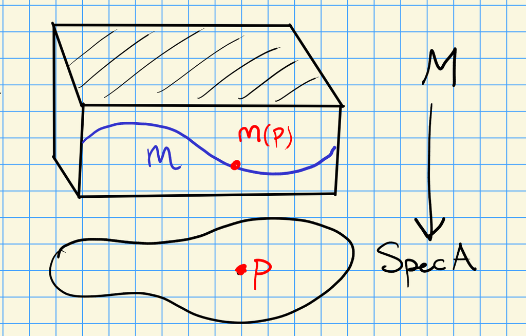

If $n\in N\in {\mathsf{A}{\hbox{-}}\mathsf{Mod}}^{\mathrm{fg}}$ and $n\equiv 0 \operatorname{mod}{\mathfrak{m}}$ for all ${\mathfrak{m}}\in \operatorname{mSpec}A$, then $M=0$.

Show that if $A \in \mathsf{Loc}\mathsf{Ring}$ and $M\in {\mathsf{A}{\hbox{-}}\mathsf{Mod}}^{\mathrm{fg}}$ with $\left\{{x_i}\right\}_{i\leq n} \subseteq M$, then
$$\begin{align*}
\left\langle{x_1,\cdots, x_n}\right\rangle = M \iff \left\langle{\mkern 1.5mu\overline{\mkern-1.5mux_1\mkern-1.5mu}\mkern 1.5mu, \cdots, \mkern 1.5mu\overline{\mkern-1.5mux_n\mkern-1.5mu}\mkern 1.5mu}\right\rangle = M/{\mathfrak{m}}M, \qquad \mkern 1.5mu\overline{\mkern-1.5mux_i\mkern-1.5mu}\mkern 1.5mu \mathrel{\vcenter{:}}= x_i \operatorname{mod}{\mathfrak{m}}
.\end{align*}$$

$\implies$: If $\mkern 1.5mu\overline{\mkern-1.5muy\mkern-1.5mu}\mkern 1.5mu\in M/{\mathfrak{m}}M$, lift to $y\in M$ to write $y = \sum c_i x_i$ and thus $\mkern 1.5mu\overline{\mkern-1.5muy\mkern-1.5mu}\mkern 1.5mu = \sum c_i \mkern 1.5mu\overline{\mkern-1.5mux_i\mkern-1.5mu}\mkern 1.5mu$.

$\impliedby$: Present $M$ by $A^n \xrightarrow{f} M \to C =\operatorname{coker}f \to 0$ where $f(e_i) = x_i$ – we want to show $C = 0$. Reduce mod ${\mathfrak{m}}$ by applying $({-})\otimes_A A/{\mathfrak{m}}$ to get
$$\begin{align*}
(A/{\mathfrak{m}})^n \xrightarrow{\mkern 1.5mu\overline{\mkern-1.5muf\mkern-1.5mu}\mkern 1.5mu} M/{\mathfrak{m}}M \to C/{\mathfrak{m}}C\to 0
.\end{align*}
This is surjective so \(C/{\mathfrak{m}}C = 0\). By Nakayama, \(C=0\).$$

Let the local ring $R = k { \left[ {t} \right] }$ with ${\mathfrak{m}}_R = \left\langle{t}\right\rangle$, and let $M = R{ {}^{ \scriptscriptstyle\oplus^{3} } }$. Consider
$$\begin{align*}
{\left[ {1+t^3 + t^5, t+t^2, t^3} \right]}, {\left[ {t^{22}, 1+t^9, t^{10} + t^{10^{10}}} \right]}, {\left[ {1+ t^{10^{10^{10}}}, 1+t^5 + t^9, 1+t^7 + t^{11} } \right]}
,\end{align*}
which reduced \(\operatorname{mod}t\) yields
\begin{align*}
{\left[ {1,0,0} \right]}, {\left[ {0,1,0} \right]}, {\left[ {1,1,1} \right]}
.\end{align*}
So the original elements generate \(M\).$$

Next goal: proving Nakayama. We’ll need a version of Cayley-Hamilton. Recall the definition of multiplicative subsets and localization, along with its universal property.

Examples:

- For any element $f$, $S\mathrel{\vcenter{:}}=\left\{{1, f, f^2,\cdots}\right\}$
- For $A$ an integral domain, $S \mathrel{\vcenter{:}}= A\setminus\left\{{0}\right\}$
- All nonzero zero divisors.

Prove $S^{-1}A$ exists and is unique for $A\in \mathsf{CRing}$. Give an example where $s'a = sb$ is not sufficient.

Remarks on localization:

- ${a\over s} = {b\over s'} \iff s'' s' a - s'' s b$ for some $s''\in S$ – this is needed because it will hold in $S^{-1}A$, since $s''\in (S^{-1}A)^{\times}$ for any $s''\in S$ by construction.
- ${a\over s}=0$ iff $a$ is annihilated by an element of $S$.
- Producing the actual map for the universal property: if $f:A\to B$ sends $S$ to invertible elements,

[figure not shown]

> Link to Diagram
- $A_f \mathrel{\vcenter{:}}= S^{-1}A$ for $S \mathrel{\vcenter{:}}=\left\{{1,f,f^2,\cdots}\right\}$. For $A = {\mathbb{Z}}$ and $f=p$ a prime, ${\mathbb{Z}}_f = {\mathbb{Z}}{ \left[ { \scriptstyle \frac{1}{p} } \right] } \subseteq {\mathbb{Q}}$ are fractions whose denominator is a power of $p$.
- For $A$ an integral domain and $S=A\setminus\left\{{0}\right\}$ yields $S^{-1}A = \operatorname{ff}(A)$ the fraction field.
- For ${\mathfrak{p}}\in \operatorname{Spec}A$, $S\mathrel{\vcenter{:}}= A\setminus{\mathfrak{p}}$, then $A_{\mathfrak{p}}\mathrel{\vcenter{:}}= S^{-1}A$ is localization at a prime ideal
- ${\mathbb{Z}}_{\left\langle{p}\right\rangle} = {\mathbb{Z}}{ \left[ { \scriptstyle \frac{1}{\ell} } \right] }_{\ell\neq p \text{ prime}}$, fractions in ${\mathbb{Q}}$ with denominators not divisible by $p$.

Some exercises:

- Use the universal property to show $({\mathbb{Z}}/15{\mathbb{Z}})_5 \cong {\mathbb{Z}}/3{\mathbb{Z}}$.
- Show that for $M\in {\mathsf{A}{\hbox{-}}\mathsf{Mod}}$, $S^{-1}M$ exists and is unique.
- Show that $S^{-1}A \curvearrowright S^{-1}M$.
- Show that $S^{-1}M = M\otimes_A S^{-1}A$ using the universal property. Use
  $$\begin{align*}
  M = M\otimes_A A \xrightarrow{\operatorname{id}\otimes S^{-1}({-})} M\otimes_A S^{-1}A
  \end{align*}
  where \(m\mapsto m\otimes 1\) For \(f:M\to N\) where \(s\) acts invertibly on \(N\), produce a map \(M\times S^{-1}A\to N\) where \((m, a/s)\mapsto as^{-1}f(m)\) where \(s^{-1}\) is the inverse of the action \(s: N\to N\).$$
- Show that $({-})\otimes_A S^{-1}A$ is left exact and thus exact.
  - Injectivity: use that ${m\over s}\mapsto 0 \iff s'f(m) = 0$ for some $s'\in S$.
- Show that $S^{-1}A \in {\mathsf{A}{\hbox{-}}\mathsf{Mod}}^\flat$.

# 7 Tuesday, February 01

For $A\in \mathsf{CRing}, M\in {\mathsf{A}{\hbox{-}}\mathsf{Mod}}^{\mathrm{fg}}$, ${\mathfrak{a}}\in \operatorname{Id}(A)$, and $\phi: M\to {\mathfrak{a}}M \subseteq M$, there exists $\left\{{a_i}\right\}_{i\leq n} \subseteq {\mathfrak{a}}$ such that
$$\begin{align*}
\phi^r + a_1 \phi^{r-1} + \cdots + a_r \operatorname{id}= 0
.\end{align*}$$

Reduce to showing this for $M = A^r$ a free module. Use the diagram:

[figure not shown]

> Link to Diagram

Lift by sending $e_i$ to any element $a_i \in {\mathfrak{a}}$. Then: STS $\tilde f$ satisfies some polynomial, since $\phi$ will satisfy the same polynomial and map to zero by commutativity of the square above. $\tilde f: A^r\to A^r$ can be written as a matrix $(a_{ij})$. Now reduce to ${\mathbb{C}}$: consider the map
$$\begin{align*}
{\mathbb{Z}}[ \left\{{ x_{ij}}\right\}_{i, j \leq r} ] &\to A \\
x_{ij} &\mapsto a_{ij}
.\end{align*}$$

Forming the matrix $M = (x_{ij})$ yields a commutative diagram:

[figure not shown]

> Link to Diagram

Since ${\mathbb{Z}}[\left\{{ x_{ij} }\right\}]$ is an integral domain, we can pass to the fraction field ${\mathbb{Q}}(\left\{{x_{ij}}\right\})$, where by linear algebra $M$ has a characteristic polynomial in the $x_{ij}$. So for some homogeneous polynomials $p_i$ in the $x_{ij}$, we have
$$\begin{align*}
\tilde f^r + p_1(x_{ij}) \tilde f^{r-1} + \cdots + p_r(x_{ij}) = 0
.\end{align*}
Now choose an arbitrary embedding \({\mathbb{Q}}(x_{ij}) \hookrightarrow{\mathbb{C}}\), and prove Cayley-Hamilton here using (e.g.) Jordan normal form.$$

Write a careful proof of Cayley-Hamilton for arbitrary fields.

Useful strategy: reduce to the “universal matrix.”

Recall that there exists an *adjugate* of any square matrix satisfying $M \operatorname{adj}(M) = \operatorname{adj}(M) M = \operatorname{det}(M) \operatorname{id}$. Apply this to $M \mathrel{\vcenter{:}}= tI - \tilde f \in \mathop{\mathrm{End}}_{A[t]}(A(t){ {}^{ \scriptscriptstyle\times^{r} } })$. Write $\operatorname{adj}(tI-\tilde f) = \sum B_i t^i$ with $B_i \in \operatorname{Mat}_{n\times n}(A)$. We have \begin{align*} (tI-\tilde f) \operatorname{adj}(tI - \tilde f) = \operatorname{det}(\tilde f)I ,\end{align*} but we can’t plug in $\tilde f$ here because we don’t know if this lands in a *commutative* ring, so e.g. $t m t^r \neq mt^{r+1}$ doesn’t necessarily hold.

Note that $B_i$ commutes with $tI - \tilde f \iff B_i$ commutes with $\tilde f$, e.g. by equating coefficients. Write $R = Z(\tilde f)$ for the centralizer, those matrices commuting with $\tilde f$. Then $(tI - \tilde f) \in R[t]$, which reduces us to the world of commutative rings. Then ${ \left.{{ \operatorname{det}(tI - \tilde f) }} \right|_{{\tilde f}} } = (\tilde f - \tilde f)\cdot g = 0$.

Show that if $M\in {\mathsf{A}{\hbox{-}}\mathsf{Mod}}^{\mathrm{fg}}$ and ${\mathfrak{a}}\in \operatorname{Id}(A)$,
$$\begin{align*}
M = {\mathfrak{a}}M \implies \exists x\cong 1{\mathsf{{\mathfrak{a}}}{\hbox{-}}\mathsf{Mod}}\text{ such that } xM = 0
.\end{align*}$$

> Hint: apply Cayley-Hamilton to $\operatorname{id}_M$.

For $M\in {\mathsf{A}{\hbox{-}}\mathsf{Mod}}^{\mathrm{fg}}, I \in \operatorname{Id}(A)$ with $I \in {J ({A}) }$,
$$\begin{align*}
M = IM \implies M = 0
.\end{align*}$$

Apply the corollary to get $x\equiv 1 \operatorname{mod}I$ with $xM = 0$. But then $x \equiv 1 \operatorname{mod}{J ({A}) }$, so $x$ is a unique and $xM = M$.

Alternatively, pick a minimal set of generators $\left\{{x_i}\right\}$ of $M$, so $m = \sum a_i x_i$ with $a_i\in I$ since $M=IM$. Since $1-a_n\in {J ({A}) }$ and is a unit, so
$$\begin{align*}
(1-a_n)x_n = \sum_{i\leq n-1} a_i x_i \implies x_n = (1-a_n)^{-1}\sum_{i\leq n-1}a_i x_i
.\end{align*}
\(\contradiction$$

Notes:

- Proved last time: $A\in \mathsf{Loc}\mathsf{Ring}, M \in {\mathsf{A}{\hbox{-}}\mathsf{Mod}}^{\mathrm{fg}}$, if $X\mathrel{\vcenter{:}}=\left\{{x_i}\right\} \subseteq M$ with $\left\{{\mkern 1.5mu\overline{\mkern-1.5mux_i\mkern-1.5mu}\mkern 1.5mu}\right\}$ generating $M/{\mathfrak{m}}M$, then $X$ generates $M$.
- Suppose $f\in {\mathsf{A}{\hbox{-}}\mathsf{Mod}}(M, N)$ with $\mkern 1.5mu\overline{\mkern-1.5muf\mkern-1.5mu}\mkern 1.5mu: M/{\mathfrak{m}}_A M \to N/{\mathfrak{m}}_A N$ an isomorphism – $f$ is not necessarily an isomorphism.
  - Counterexample: $k[[x]]\to k$ is not an isomorphism in ${\mathsf{k}{\hbox{-}}\mathsf{Mod}}$ but reduces mod $x$ to $k \xrightarrow{\operatorname{id}} k$.
- Show that $f$ need not be injective, but is always surjective.
  - For surjectivity: use $M \xrightarrow{f} N \to C \to 0$, use that $C/{\mathfrak{m}}C =0$ to conclude $C=0$ by Nakayama.
  - For injectivity: use $0\to K\to M \xrightarrow{f} N \to 0$ and try to show $K=0$. Not true, take $0\to \left\langle{x}\right\rangle \to k[[x]] \to k\to 0$ and apply $({-})\otimes_{k[[x]]} k$ to get $k \xrightarrow{0} k \xrightarrow{\operatorname{id}} k\to 0$.
- The special SES $0\to M \to M \oplus N \to N \to 0$ has a left-section $s: M \oplus N\to M$; applying $({-})\otimes_A S$ or $\mathop{\mathrm{Hom}}_A(S, {-})$ actually produces a SES, since this induces left sections on the resulting sequences.
- Prove that free modules are projective.
- Prove that divisible abelian groups are injective in ${\mathsf{{\mathbb{Z}}}{\hbox{-}}\mathsf{Mod}}$.
  - Prove that ${\mathbb{Q}}$ and ${\mathbb{Q}}/{\mathbb{Z}}$ are injective.
- Show that a SES splits iff it admits a right section or a left section.
- Show that $0\to I\to M\to P\to 0$ splits if either $P$ is projective or $I$ is injective.
- Show that $({-})\otimes_A S, \mathop{\mathrm{Hom}}_A({-}, S), \mathop{\mathrm{Hom}}_A(S, {-})$ are exact on SES’s $0\to A\to B \to P\to 0$ with $P$ projective.

# 8 Thursday, February 03

Exercises:

- Find a way to remember which $\hom$ is covariant vs contravariant.
- Show $P$ is projective $\iff \mathop{\mathrm{Hom}}(P, {-})$ is exact, $I$ is injective $\iff \mathop{\mathrm{Hom}}({-}, I)$ is exact (sends injections to surjections).
- Find a non-free projective module.
- Show that $P$ is projective iff $P$ is a direct summand of a free module. Use that $0\to K\to A{ {}^{ \scriptscriptstyle\oplus^{I} } } \to P\to 0$ and lift $P \xrightarrow{\operatorname{id}_P} P$ to get $A{ {}^{ \scriptscriptstyle\oplus^{I} } } = K \oplus P$. For the other direction:

[figure not shown]

> Link to Diagram
- Show that in ${\mathbb{Z}{\hbox{-}}\mathsf{Mod}}$, $I$ is injective iff divisible.
  - For one direction, show $ni' = i$ using the following diagram:

[figure not shown]

> Link to Diagram
- For the other direction, produce a map:

[figure not shown]

> [Link to Diagram](https://q.uiver.app/?q=WzAsNCxbMCwwLCIwIl0sWzIsMCwiWCJdLFs0LDAsIlkiXSxbMiwyLCJJIl0sWzAsMV0sWzEsMl0sWzEsM10sWzIsMywiXFxleGlzdHMgPyIsMSx7InN0eWxlIjp7ImJvZHkiOnsibmFtZSI6ImRhc2hlZCJ9fX1dXQ==)
- Use Zorn’s lemma on pairs $(Y, f)$ where $(Y, f) \leq (Y', g) \iff Y \subseteq Y'$ and ${ \left.{{g}} \right|_{{Y}} } = f$. Show every chain has an upper bound by setting $Y_\infty = \displaystyle\bigcup Y_i$ and $f_\infty = \cup f_i$, thus producing $Y_{\mathrm{max}}, f_{\mathrm{max}}$ Take a SES $0 \to \left\langle{y}\right\rangle \to \left\langle{y, Y_{\mathrm{max}}}\right\rangle \to \left\langle{y, Y_{\mathrm{max}}}\right\rangle/\left\langle{y}\right\rangle\to 0$ and map the last term to $I$.
- Recall that projective resolutions are complexes ${ {P}_{\scriptscriptstyle \bullet}} = \cdots P_1\to P_0\to 0$ with $H_{i>0}{ {P}_{\scriptscriptstyle \bullet}} = 0$ and $H_0{ {P}_{\scriptscriptstyle \bullet}} = M$, equivalently an exact complex $\cdots\to P_1\to P_0\to M\to 0$.
- Find a projective resolution of $C_2\in{\mathbb{Z}{\hbox{-}}\mathsf{Mod}}$ and $k[t]/\left\langle{t^2}\right\rangle\in {\mathsf{k}{\hbox{-}}\mathsf{Mod}}$. Why must the latter necessarily be infinite length?
- Compute $\operatorname{Tor}_*^{\mathbb{Z}}(C_2, C_2) \in {\mathbb{Z}{\hbox{-}}\mathsf{Mod}}$ and $\operatorname{Tor}_*^{\mathbb{Z}}({\mathbb{Z}}{ {}^{ \scriptscriptstyle\oplus^{2} } }, C_2)$.
- Show $\operatorname{Tor}_*^{R}(k, k) = \bigoplus_{i\geq 0} k$ for $R = k[t]/\left\langle{t^2}\right\rangle$? Use the resolution $P_i = k[t]/\left\langle{t^2}\right\rangle$ with maps $({-})\times t$, using that $t\curvearrowright k$ by zero.
- Show that if $f\simeq g$, then $f-g$ induces the zero map in homology. Use $d_{i+1} s_i + s_{i-1} d_i: H_i(C)\to H_i(D)$, pick $\mkern 1.5mu\overline{\mkern-1.5mux\mkern-1.5mu}\mkern 1.5mu\in C_i$ with $d_i \mkern 1.5mu\overline{\mkern-1.5mux\mkern-1.5mu}\mkern 1.5mu = 0$ and check $(d_{i+1} s_i + s_{i-1} d_{i})\mkern 1.5mu\overline{\mkern-1.5mux\mkern-1.5mu}\mkern 1.5mu\in \operatorname{im}d_{i+1}$.

# 9 Tuesday, February 08

Show that chain-homotopic maps induce the same map in homology.

${ {\operatorname{Tor}}_{\scriptscriptstyle \bullet}} ^{{\mathsf{R}{\hbox{-}}\mathsf{Mod}}}(M, N)$ for $M, N\in {\mathsf{R}{\hbox{-}}\mathsf{Mod}}$ is well-defined, since the identity $M \xrightarrow{\operatorname{id}_M} M$ induces an isomorphism on ${ {P}_{\scriptscriptstyle \bullet}} \otimes N \to { {P}_{\scriptscriptstyle \bullet}} '\otimes N$ for any two projective resolution ${ {P}_{\scriptscriptstyle \bullet}} , { {P}_{\scriptscriptstyle \bullet}} ' \rightrightarrows M$.

If $f\in {\mathsf{R}{\hbox{-}}\mathsf{Mod}}(M, N)$, then there is an induced morphism $\tilde f\in \mathsf{Ch}{\mathsf{R}{\hbox{-}}\mathsf{Mod}}({ {P}_{\scriptscriptstyle \bullet}} ^M, { {P}_{\scriptscriptstyle \bullet}} ^N)$ between resolutions ${ {P}_{\scriptscriptstyle \bullet}} ^M\rightrightarrows M, { {P}_{\scriptscriptstyle \bullet}} ^N\rightrightarrows N$, where $\tilde f$ is unique up to homotopy.

For existence, use projectivity to lift through surjections onto kernels. For uniqueness, create $s_0$ such that $d_1 s_0 = d_0-g_0$ and check that $\operatorname{im}f_0 - g_0 \subseteq \ker d_0$ after lifting through $P_1^N\to \ker d_0$:

[figure not shown]

> Link to Diagram

Show that a SES of modules induces a SES of chain complexes between their projective resolutions.

Hint: use the following diagram.

[figure not shown]

> Link to Diagram

Show that a SES of chain complexes induces a LES in their homology. There are about eight conditions one needs to check here (as in the snake lemma, of which this is a special case for two-term complexes).

Show that given $0\to M_1 \to M_2\to M_3\to 0$, taking projective resolutions and applying $({-})\otimes N$ yields a SES
$$\begin{align*}
0\to { {P}_{\scriptscriptstyle \bullet}} ^1\otimes N \to { {P}_{\scriptscriptstyle \bullet}} ^2\otimes N \to { {P}_{\scriptscriptstyle \bullet}} ^3\otimes N\to 0
,\end{align*}
so there is an induced LES in \({ {\operatorname{Tor}}_{\scriptscriptstyle \bullet}} ^{{\mathsf{R}{\hbox{-}}\mathsf{Mod}}}\).$$

Show

- $\operatorname{Tor}_0^{{\mathsf{R}{\hbox{-}}\mathsf{Mod}}}(M, N) = M\otimes_R N$
- $\tau_{\geq 1} { {\operatorname{Tor}}_{\scriptscriptstyle \bullet}} ^{{\mathsf{R}{\hbox{-}}\mathsf{Mod}}}(M, N) = 0$ if either $M$ or $N$ is projective.
- ${ {\operatorname{Tor}}_{\scriptscriptstyle \bullet}} ^R(M, N)$ is uniquely determined by these properties.

Hint:
$$\begin{align*}
\operatorname{Tor}_0^{{\mathsf{R}{\hbox{-}}\mathsf{Mod}}}(M, N)
&= H_0({ {P}_{\scriptscriptstyle \bullet}} ^M \otimes_R N) \\
&= \operatorname{coker}\qty{P_1\otimes N \to P_0\otimes_R N}\\
&= \operatorname{coker}(P_1\to P_0) \otimes_R N \\
&= M\otimes_R N
.\end{align*}$$

For vanishing, use that projective implies flat and exact complexes have zero higher homology. Note that if $M$ is projective, it is its own projective resolution.

For uniqueness, induct on $i$: write $0\to K \to R{ {}^{ \scriptscriptstyle\oplus^{J} } }\to M\to 0$, use that free implies projective, and consider the LES:

[figure not shown]

> Link to Diagram

Now induct up using the isomorphisms in the LES.

Show that
$$\begin{align*}
{ {\operatorname{Tor}}_{\scriptscriptstyle \bullet}} ^{{\mathsf{R}{\hbox{-}}\mathsf{Mod}}}(M, N) \cong {{ {H}_{\scriptscriptstyle \bullet}} }({ {P}_{\scriptscriptstyle \bullet}} ^M \otimes_R N) \cong {{ {H}_{\scriptscriptstyle \bullet}} }(M\otimes_R { {P}_{\scriptscriptstyle \bullet}} ^N )\cong { { \operatorname{Tor}}_{\scriptscriptstyle \bullet}} ^{{\mathsf{R}{\hbox{-}}\mathsf{Mod}}}(N, M)
.\end{align*}$$

# 10 Thursday, February 10

Let $R= k[x,y]$ and $M = k \cong k[x,y]/\left\langle{x, y}\right\rangle$, and compute ${ {\operatorname{Tor}}_{\scriptscriptstyle \bullet}} ^{{\mathsf{R}{\hbox{-}}\mathsf{Mod}}}(k, k)$.

Hint: use the following resolution

[figure not shown]

> Link to Diagram

Compute ${ {\operatorname{Tor}}_{\scriptscriptstyle \bullet}} ^{{\mathsf{R}{\hbox{-}}\mathsf{Mod}}}(k, k)$ for $R=k[x_1, \cdots, x_{n}]$ and $M = k = k[x_1, \cdots, x_{n}]/\left\langle{x_1,\cdots, x_n}\right\rangle$.

$\operatorname{Tor}$ measures failure of injectivity of tensoring against a module $M$, ${ {\operatorname{Ext} }^{\scriptscriptstyle \bullet}}$ measures failure of surjectivity when mapping against $M$.

Show that for $R\in\mathsf{CRing}$, every $M\in{\mathsf{R}{\hbox{-}}\mathsf{Mod}}$ admits an injective resolution.

Hint: it suffices to show any $M$ injects into an injective object. Use the following diagram:

[figure not shown]

> Link to Diagram

First show this for $R={\mathbb{Z}}$ using that ${\mathbb{Q}}{ {}^{ \scriptscriptstyle\oplus^{J} } }/K$ is divisible and thus injective:

[figure not shown]

> Link to Diagram

Now reduce to $R={\mathbb{Z}}$ using that $M\hookrightarrow D$ for $D$ a divisible abelian group, and show $M\hookrightarrow I \mathrel{\vcenter{:}}=\mathop{\mathrm{Hom}}_{{\mathbb{Z}{\hbox{-}}\mathsf{Mod}}}(R, D)\in{\mathsf{R}{\hbox{-}}\mathsf{Mod}}$. Form the map as the composition:

[figure not shown]

> Link to Diagram

Then show that $I\mathrel{\vcenter{:}}=\mathop{\mathrm{Hom}}_{{\mathbb{Z}{\hbox{-}}\mathsf{Mod}}}(R, D)$ is injective using the universal property:

[figure not shown]

> Link to Diagram

Show ${\mathbb{Z}}\in {\mathbb{Z}{\hbox{-}}\mathsf{Mod}}$ has an injective resolution.

$$\begin{align*}
0 \to {\mathbb{Z}}\hookrightarrow{\mathbb{Q}}\twoheadrightarrow{\mathbb{Q}}/{\mathbb{Z}}\to 0
.\end{align*}$$

Show ${ {\operatorname{Ext} }^{\scriptscriptstyle \bullet}} _{{\mathbb{Z}{\hbox{-}}\mathsf{Mod}}}(C_3, {\mathbb{Z}}) \cong C_3[1]$.

> Hint: apply $\mathop{\mathrm{Hom}}_{{\mathbb{Z}{\hbox{-}}\mathsf{Mod}}}(C_3, {-})$ to the above resolution and use $\mathop{\mathrm{Hom}}_{{\mathbb{Z}{\hbox{-}}\mathsf{Mod}}}(C_3, {\mathbb{Q}}/{\mathbb{Z}}) \cong C_3$

Show that if $f\in {\mathsf{R}{\hbox{-}}\mathsf{Mod}}(M, N)$ then there is an induced chain map $\tilde f\in \mathsf{Ch}{\mathsf{R}{\hbox{-}}\mathsf{Mod}}( { {I}^{\scriptscriptstyle \bullet}} _M, { {I}^{\scriptscriptstyle \bullet}} _N)$ which is unique up to homotopy. Conclude that ${ {\operatorname{Ext} }^{\scriptscriptstyle \bullet}} _{{\mathsf{R}{\hbox{-}}\mathsf{Mod}}}(M, N)$ is independent of injective resolution.

> Hint: take $f=\operatorname{id}_M$.

Show that if $0\to A\to B\to C\to 0$ is a SES in ${\mathsf{R}{\hbox{-}}\mathsf{Mod}}$ with ${ {I}^{\scriptscriptstyle \bullet}} _A \leftleftarrows A, { {I}^{\scriptscriptstyle \bullet}} _C\leftleftarrows B$, then there is a complex ${ {I}^{\scriptscriptstyle \bullet}} _B\leftleftarrows B$ making $0\to { {I}^{\scriptscriptstyle \bullet}} _A \to { {I}^{\scriptscriptstyle \bullet}} _B \to { {I}^{\scriptscriptstyle \bullet}} _C \to 0$ a SES in $\mathsf{Ch}{\mathsf{R}{\hbox{-}}\mathsf{Mod}}$.

Show that a SES in ${\mathsf{R}{\hbox{-}}\mathsf{Mod}}$ induces a LES in ${ {\operatorname{Ext} }^{\scriptscriptstyle \bullet}} _{{\mathsf{R}{\hbox{-}}\mathsf{Mod}}}$. Do this for both homs: start with $0\to A\to B\to C\to 0$, and produce a LES for ${ {\operatorname{Ext} }^{\scriptscriptstyle \bullet}} _{{\mathsf{R}{\hbox{-}}\mathsf{Mod}}} (M, {-})$ and ${ { \operatorname{Ext} }^{\scriptscriptstyle \bullet}} _{{\mathsf{R}{\hbox{-}}\mathsf{Mod}}}({-}, M)$.

> Hint: for the first case, apply $\mathop{\mathrm{Hom}}_{{\mathsf{R}{\hbox{-}}\mathsf{Mod}}}(M, {-})$ to the SES of chain complexes of injective resolutions, and use that if $I_1$ is injective then the SES splits. For the second, use that $\mathop{\mathrm{Hom}}({-}, I)$ is exact iff $I$ is injective and take an injective resolution of $M$.

Show that ${ { \operatorname{Ext} }^{\scriptscriptstyle \bullet}} _{{\mathsf{R}{\hbox{-}}\mathsf{Mod}}}(M, N)$ is uniquely characterized by

1. $\operatorname{Ext} ^0_{{\mathsf{R}{\hbox{-}}\mathsf{Mod}}}(M, N) \cong \mathop{\mathrm{Hom}}_{{\mathsf{R}{\hbox{-}}\mathsf{Mod}}}(M, N)$
2. $\tau_{\geq 1} { {\operatorname{Ext} }^{\scriptscriptstyle \bullet}} _{{\mathsf{R}{\hbox{-}}\mathsf{Mod}}}(M, N) = 0$ if $M$ is projective or $N$ is injective.
3. The two LESs above exist.

Hints:

- Resolve ${ {I}^{\scriptscriptstyle \bullet}} _N \leftleftarrows N$, apply $\mathop{\mathrm{Hom}}_{{\mathsf{R}{\hbox{-}}\mathsf{Mod}}}(M,{-})$, and identify $\operatorname{Ext} ^0_{{\mathsf{R}{\hbox{-}}\mathsf{Mod}}}$ as a kernel.
- $N$ is its own injective resolution when $N$ is injective.
- $\mathop{\mathrm{Hom}}_{{\mathsf{R}{\hbox{-}}\mathsf{Mod}}}(M,{-})$ is exact when $M$ is projective.
- For uniqueness, use that if $0\to N\to I \to C\to 0$ with $I$ injective, then the middle terms in the LES vanish to get isomorphisms.

# 11 Tuesday, February 15

Check that $\operatorname{Ext} _R^i(M, {-})$ is independent of injective resolutions, and $\operatorname{Ext} _R^i({-}, N)$ is independent of projective resolutions.

Check that ${ {\operatorname{Ext} }^{\scriptscriptstyle \bullet}}$ is determined by

- $\operatorname{Ext} ^0 = \mathop{\mathrm{Hom}}$
- $\operatorname{Ext} ^{i>0}(P, I) = 0$ if $P$ is projective or $I$ is injective.
- It extends SESs to LESs

Show
$$\begin{align*}
{ {\operatorname{Ext} }^{\scriptscriptstyle \bullet}} _{k[t]/\left\langle{t^2}\right\rangle } (k, k) = \bigoplus_{i\geq 0} k[i]
.\end{align*}
Use the projective resolution with entries \(k[t]/\left\langle{t^2}\right\rangle\) with differential \({\partial}= \cdot t$$

Compute ${ {\operatorname{Ext} }^{\scriptscriptstyle \bullet}} _{k[x_1, \cdots, x_{n}]}(k, k)$ using the Koszul resolution ${ {\bigwedge\nolimits}^{\scriptscriptstyle \bullet}} k[x_1, \cdots, x_{n}]\rightrightarrows k$.

Defining Noetherian rings and modules:

- $A\in \mathsf{CRing}$ is Noetherian iff every $\operatorname{Id}(A) \subseteq {\mathsf{R}{\hbox{-}}\mathsf{Mod}}^{\mathrm{fg}}$.
- $M\in {\mathsf{A}{\hbox{-}}\mathsf{Mod}}$ is Noetherian iff every $N\leq M$ satisfies $N\in {\mathsf{A}{\hbox{-}}\mathsf{Mod}}^{\mathrm{fg}}$

> Thank you Emmy Noether!!

Show that TFAE:

- $R$ is Noetherian
- Every $M\in {\mathsf{R}{\hbox{-}}\mathsf{Mod}}^{\mathrm{fg}}$ is Noetherian.

For $1\implies 2$, it STS that $R^n$ is Noetherian. To reduce, use the diagram

[figure not shown]

> Link to Diagram

To show $R^n$ is Noetherian, use induction since we know $R^1$ is Noetherian. Use the following diagram, using the snake lemma on $s_1, s_3$ to show $s_2$ is surjective:

[figure not shown]

> Link to Diagram

Show TFAE:

- $M \in {\mathsf{A}{\hbox{-}}\mathsf{Mod}}$ is Noetherian.
- The ACC for submodules.

Hint: for $1\implies 2$, set $M_\infty = \displaystyle\bigcup_i M_i \leq M \in {\mathsf{A}{\hbox{-}}\mathsf{Mod}}$. Write $M_i = \left\langle{x_1,\cdots, x_n}\right\rangle$ and use that each $x_k \in M_{i_k}$ to choose $N\gg 1$ with $M_\infty = M_N$. For $2\implies 1$, for $M$ non-Noetherian find $S\leq M$ infinitely generated as $S = \left\langle{x_1,\cdots}\right\rangle$ and take the chain $\left\{{S_k}\right\}_{k\geq 0}$ where $S_k = \left\langle{x_1,\cdots, x_k}\right\rangle$.

Show that the following are Noetherian:

- Fields
- PIDs
- $R/I$ for $R$ Noetherian and $I$ arbitrary
- For $A$ Noetherian, $A[x]$ (Hilbert’s basis theorem).[^1]
  - Similarly $A{\left[\left[ x \right]\right] }$.
- Localizations of Noetherian rings

If $A$ a Noetherian local ring and $M \in {\mathsf{A}{\hbox{-}}\mathsf{Mod}}^{{\mathrm{fg}}, \mathop{\mathrm{proj}}}$, then $M$ is free.

Prove this!

Hints:

- Surjectivity:
  - Choose a basis $M/{\mathfrak{m}}M = \left\langle{\left\{{ \mkern 1.5mu\overline{\mkern-1.5mux\mkern-1.5mu}\mkern 1.5mu}\right\}_{k\leq n} }\right\rangle$ and lifts $x_k$ to $M$.
  - Take a surjective map $A^n \to M$ where $e_i \mapsto x_i$.
  - Take the SES $A^n \xrightarrow{f} M \twoheadrightarrow\operatorname{coker}f\to 0$ and apply $({-})\otimes_A A/{\mathfrak{m}}$; use that $(A/{\mathfrak{m}})^n { \, \xrightarrow{\sim}\, }M/{\mathfrak{m}}M$ and apply Nakayama.
- Injectivity:
  - Write $0\to K = \ker f \to A^n \xrightarrow{f} M \to 0$ and apply $({-})\otimes_A A/{\mathfrak{m}}$ to get
    $$\begin{align*}
    \cdots \to \operatorname{Tor}^0(M, A/{\mathfrak{m}}) \to K/{\mathfrak{m}}K \to (A/{\mathfrak{m}})^n { \, \xrightarrow{\sim}\, }M/{\mathfrak{m}}M\to 0
    ,\end{align*}
    then \(K/{\mathfrak{m}}K = 0\) and apply Nakayama to conclude \(K=0\).$$

Try an example: $k[x]\in {\mathsf{k}{\hbox{-}}\mathsf{Mod}}$, which is free after reduction mod ${\mathfrak{m}}= \left\langle{x}\right\rangle$ but not free before reduction.

Note that this works with projective replaced by flat.

Why care about Noetherian rings? Hilbert studied group actions $G$ on modules over (say) polynomial rings and wanted to find the submodules of $G{\hbox{-}}$invariants. There was an industry of writing down generating sets in order to show existence and finiteness, and the basis theorem (which is partially effective) showed that this is no longer necessary – finite generating sets always exist.

If $A$ is Noetherian then $A[x]$ is Noetherian.

Fix $U \subseteq A[x]$ an ideal, so $I = \left\{{f\in I{~\mathrel{\Big\vert}~}f = \sum a_{f, i} x^i}\right\}$. Write $J = \left\langle{a_{f, \deg f}}\right\rangle$ be the ideal generated by all leading coefficients of elements in $I$. Since $A$ is Noetherian, $J$ is finitely-generated, so write $J = \left\langle{a_1,\cdots, a_n}\right\rangle$ and choose $\left\{{f_1,\cdots, f_n}\right\}$ so that $a_i$ is the leading coefficient of $f_i$. Note that these exist since $J = A\left\{{a_1,\cdots, a_n}\right\}$ (i.e. these already form an ideal). Consider $L\mathrel{\vcenter{:}}= I \cap A[x]^{\deg \leq d}$: since $A$ is Noetherian, $A[x]^{\deg \leq d} \in {\mathsf{A}{\hbox{-}}\mathsf{Mod}}^{\mathrm{fg}}$, and $L$ also forms a finitely generated $A{\hbox{-}}$module. Write the generators as $L = \left\{{g_1,\cdots, g_m}\right\}$.

$$\begin{align*}
I = I_{fg} \mathrel{\vcenter{:}}=\left\langle{f_1,\cdots, f_n, g_1,\cdots, g_m}\right\rangle
.\end{align*}$$

If not, pick $f\in I\setminus I_{fg}$ of minimal degree. Then $\deg f > d$ by construction of $L$. Write $f = \sum b_i x^i$ where $b_{\deg f} = \sum c_i a_i$, and check $f - \sum c_i f_i x^{\deg f - \deg f_i}\in I$.

Idea: the $f_k$ take care of low degree elements, the $g_k$ knock things down in degree.

Any quotient $k[x_1, \cdots, x_{n}]/I$ is Noetherian, as is ${\mathbb{Z}}[x_1,\cdots, x_n]/I$.

Some examples:

- $k[x_1,\cdots, ]$ is not Noetherian: take $I = \left\langle{x_1,\cdots}\right\rangle$.
- $k[t. t^{1\over 2}, t^{1\over 3}, t^{1\over 4},\cdots]$.
- ${\mathbb{Z}} { \left[ \scriptstyle { \left\{{ 2^{1\over n}}\right\}_{n\geq 0} } \right] }$. Note this is countable!

Next time: other finiteness conditions, integrality, the Nullstellensatz.

# 12 Thursday, February 17

Prove the correspondence theorem between $\operatorname{Id}(A)$ and $\operatorname{Id}(S^{-1}A)$.

[figure not shown]

> Link to Diagram

Use that

- $\iota^{-1}I\in \operatorname{Id}(A)$
- $\iota(\iota^{-1}(I))$ generates $I$.
- ${a\over s} = {1\over s}{a\over 1}$ and ${a\over 1}$ is in the image of the lower map.

Show that the localization of any Noetherian ring is again Noetherian.

Say $M\in {\mathsf{R}{\hbox{-}}\mathsf{Mod}}^{ \operatorname{fp} }$ iff there is an exact sequence $R^a\to R^b\to M\to 0$. Show that if $R$ is Noetherian, ${\mathsf{R}{\hbox{-}}\mathsf{Mod}}^{ \operatorname{fp} }= {\mathsf{R}{\hbox{-}}\mathsf{Mod}}^{{\mathrm{fg}}}$.

For $f\in \mathsf{CRing}(A, B)$ and $b\in B$ define
$$\begin{align*}
f_b: A[x] &\to B \\
x&\mapsto b \\
\sum a_i x^j &\mapsto \sum f(a_i) b^i
.\end{align*}
The element \(b\) is integral over \(A\) iff \(\operatorname{im}f_b \in {\mathsf{A}{\hbox{-}}\mathsf{Mod}}^{\mathrm{fg}}\). The ring \(B\) is integral over \(A\) iff every \(b\in B\) is integral over \(A\) as above.$$

Show that ${\mathbb{Z}}{ \left[ { \scriptstyle \frac{1}{2} } \right] } \subseteq {\mathbb{Q}}$ is not integral.

Show TFAE:

- $b$ is integral over $A$
- $b$ satisfies a monic polynomial over $A$, so $b^n + \sum_{i = 1}^n a_i b^{n-i} = 0$.

Hints:

- Write $\operatorname{im}f_b = I\mathrel{\vcenter{:}}=\left\langle{1,b,\cdots, b^{n-1}}\right\rangle$, suppose $b^n\in I$, and show $b^{n+1} \in I$ by expanding as a sum.
- Set $M_i = \left\langle{1,b, \cdots, b^i}\right\rangle$ and use that these stabilize to conclude $b^n \in M_{n-1}$ for some $n$.

$B$ Noetherian over $A$ does not imply $B$ is Noetherian! Consider $\mkern 1.5mu\overline{\mkern-1.5mu{\mathbb{Z}}\mkern-1.5mu}\mkern 1.5mu$, the algebraic integers, which is integral over ${\mathbb{Z}}$. Note that $\left\langle{2^{1\over n}}\right\rangle$ is not finitely-generated.

# 13 Toward the Nullstellensatz

Idea: there is a dictionary between $k[x_1, \cdots, x_{n}]$ and ${\mathbb{A}}^n_{/ {k}}$ for $k= { \mkern 1.5mu\overline{\mkern-1.5muk\mkern-1.5mu}\mkern 1.5mu }$:

- Points in ${\mathbb{A}}^n$ correspond to maps $k[x_1, \cdots, x_{n}]\to k$ given by $x_i\mapsto c_i\in k$.
- Rings $R$ correspond to their prime spectra $\operatorname{Spec}R$.
- Kernels correspond to maximal ideals
- Ideals $I\in \operatorname{Id}(R)$ correspond to $V(I) =\left\{{{\mathfrak{m}}{~\mathrel{\Big\vert}~}I \subseteq {\mathfrak{m}}}\right\}$
- Ideals $I\in \operatorname{Id}(k[x_1, \cdots, x_{n}])$ correspond to $V(I) = \left\{{\mathbf{c}\in k{ {}^{ \scriptscriptstyle\times^{n} } } {~\mathrel{\Big\vert}~}f(\mathbf{c}) = 0 \, \forall f\in I}\right\}$.

Any ${\mathfrak{m}}\in \operatorname{mSpec}k[x_1, \cdots, x_{n}]$ is given by $\ker \pi_p$ for some morphism
$$\begin{align*}
\pi_p: k[x_1, \cdots, x_{n}]\to k \\
x_i &\mapsto c_i
\end{align*}
for some \(p = {\left[ {c_1,\cdots, c_n} \right]} \in k{ {}^{ \scriptscriptstyle\times^{n} } }\). Equivalently, \({\mathfrak{m}}= \left\langle{x_1-c_1,\cdots, x_n - c_n}\right\rangle\).$$

If $f\in k[x_1, \cdots, x_{n}]$ satisfies ${ \left.{{f}} \right|_{{V(I)}} } = 0$ for a fixed $I\in \operatorname{Id}(k[x_1, \cdots, x_{n}])$, then $f^n\in I$ for some $n>0$. I.e. there is a bijective correspondence $I\rightleftharpoons V(I)$ for radical ideals $\sqrt{I} = I$.

Necessity of conditions:

- Why $k= { \mkern 1.5mu\overline{\mkern-1.5muk\mkern-1.5mu}\mkern 1.5mu }$ is needed: take $\left\langle{x^-2}\right\rangle\in {\mathbb{Q}}[x]$, this is a maximal ideal but $V(I) = 0$.
- Why the radical condition is needed: take $I = \left\langle{x^{10} }\right\rangle$ so $V(I) = \left\{{0}\right\} \subseteq k$, but ${ \left.{{x}} \right|_{{V(I)}} } = 0$.

For $k= { \mkern 1.5mu\overline{\mkern-1.5muk\mkern-1.5mu}\mkern 1.5mu }$ and $R\in {\mathsf{Alg}_{/k} }^{\mathrm{fg}}$,
$$\begin{align*}
\operatorname{mSpec}R \rightleftharpoons\mathop{\mathrm{Hom}}_{{\mathsf{Alg}_{/k} }}(R, k)
.\end{align*}$$

$V(f) = k{ {}^{ \scriptscriptstyle\times^{n} } } = V(0)$ iff $f\in {\sqrt{0_{R}} }$.

Let $R\in {\mathsf{Alg}_{/k} }^{\mathrm{fg}}$, so $R = k[x_1, \cdots, x_{n}]/I$ for some $n$, and let $V(I) \subseteq k{ {}^{ \scriptscriptstyle\times^{n} } }$. Given $J \subseteq R$ radical, $V(J) \subseteq V(I)$, and $f\in R$ vanishes on $V(J)$ iff $f^n\in J$ for some $n>0$.

For $k= { \mkern 1.5mu\overline{\mkern-1.5muk\mkern-1.5mu}\mkern 1.5mu }$ and $A\in {\mathsf{Alg}_{/k} }^{\mathrm{fg}}$ with ${\mathfrak{m}}\in \operatorname{mSpec}A$,
$$\begin{align*}
A/{\mathfrak{m}}\cong k
.\end{align*}$$

For $k$ an arbitrary field and $A\in {\mathsf{Alg}_{/k} }^{\mathrm{fg}}$ with ${\mathfrak{m}}\in \operatorname{mSpec}A$,
$$\begin{align*}
A/{\mathfrak{m}}
\text{ is a finite extension of } k
.\end{align*}$$

If $k \subseteq F$ fields with $F\in {\mathsf{Alg}_{/k} }^{\mathrm{fg}}$, then $F_{/ {k}}$ is a finite extension of fields.

If $R\in {\mathsf{Alg}_{/{\mathbb{Z}}}}^{\mathrm{fg}}$ and ${\mathfrak{m}}\in \operatorname{mSpec}R$, then $R/{\mathfrak{m}}$ is finite.

Check ${\mathfrak{m}}\cap{\mathbb{Z}}= {\mathfrak{p}}\in \operatorname{Spec}{\mathbb{Z}}$ and $R/{\mathfrak{m}}$ is a finitely generated extension of ${\mathbb{F}}_p$ and hence finite.

If $A\in \mathsf{CRing}^{ \mathrm{Noeth} }$ and $A \subseteq B \subseteq C$ with

- $C\in {{A}{\hbox{-}}\mathsf{Alg}}^{\mathrm{fg}}$ and
- $C\in {\mathsf{B}{\hbox{-}}\mathsf{Mod}}^{\mathrm{fg}}$,

then $B\in {{A}{\hbox{-}}\mathsf{Alg}}^{\mathrm{fg}}$.

Sketch:

- Choose $x_1,\cdots, x_n$ generating $C$ as an $A{\hbox{-}}$algebra
- Choose $y_1,\cdots, y_m$ generating $C$ as a $B{\hbox{-}}$module.
- Write $x_i = \sum_j b_{ij} y_j$ with $b_{ij}\in B$
- Write $x_i x_j = \sum_k b_{ijk} y_k$ with $b_{ijk}\in B$
- Let $B_0 \subseteq B$ be the $A{\hbox{-}}$algebra generated by the $b_{ij}$ and $b_{ijk}$.
- Observe that $B_0$ is Noetherian by the Hilbert basis theorem since it’s finitely generated as an $A{\hbox{-}}$algebra.
- For any $c\in C$, write $c = \sum_i b_i y_i$ since the $y_i$ generate $C$ as a $B_0$ module.
- Idea: can rewrite in terms of lower degree monomials?
- Since each $b_i = \sum a_{I}^i x^I$, we have $c = \sum_i \sum_I a_I^i x^I y_i$, which is a polynomial in $\sum b_{ij} y_j$.
- Then $y_{i} \cdots y_{i_k} = \sum p_s y_s$ where the $p_s$ are polynomials in the $b_{ijk}$?
- Since $B_0$ is Noetherian and $B \subseteq C$, $B$ is finitely generated as a $B_0$ module and thus as a $B_0$ algebra.
- Since $A \subseteq B_0 \subseteq B$ and $B_0$ is finitely-generated as an $A$ algebra and $B$ is finitely-generated as a $B_0$ algebra, we have that $B$ is finitely-generated as an $A$ algebra.

# 14 Thursday, February 24

## 14.1 Going up, going down

Let $A \subseteq B\in \mathsf{CRing}$ with $B$ integral over $A$. Then for every $p\in \operatorname{Spec}A$ there is a $q\in \operatorname{Spec}B$ with $p = A \cap q$.

Idea: $\operatorname{Spec}B\to \operatorname{Spec}A$ has finite fibers.

If $A \hookrightarrow B$ is an integral extension, then $A\in \mathsf{Field}\iff B\in \mathsf{Field}$.

$\implies$: Last time.

$\impliedby$: Given $x\in A$ we have $x^{-1}\in A$. Then if $f(x) = x^{-n} + \sum_{0\leq k \leq n-1} a_k x^{-k}$, with $f(x) = 0$, then $x^{n-1}f(x) = 0 \implies x^{-1}= -\sum a_k x^k \in A$.

Note $A \left[ { \scriptstyle { {p}^{-1}} } \right] \hookrightarrow B \left[ { \scriptstyle { {p}^{-1}} } \right]$ is still integral, and let $q'\in \operatorname{mSpec}B \left[ { \scriptstyle { {p}^{-1}} } \right] \neq \emptyset$. Write $p$ for the maximal ideal of $A$, then (claim) $A \left[ { \scriptstyle { {p}^{-1}} } \right] \cap q' = p$. STS $A \left[ { \scriptstyle { {p}^{-1}} } \right] \cap q'$ is maximal, since these are local rings, and so it’s ETS $A \left[ { \scriptstyle { {p}^{-1}} } \right]/(A \left[ { \scriptstyle { {p}^{-1}} } \right] \cap q') \in \mathsf{Field}$. Since this is integral iff $B \left[ { \scriptstyle { {p}^{-1}} } \right]/q'$ is integral, which it is, by the lemma this is a field too.

Show tat taking the preimage of $q'$ in $B$ works.

Given $A \hookrightarrow B$ integral and
$$\begin{align*}
p_1 &\subseteq p_2 \subseteq \cdots \subseteq p_n \in \operatorname{Spec}A \\
q_1 &\subseteq q_2 \subseteq \cdots \subseteq q_m \in \operatorname{Spec}B \\
,\end{align*}
where \(p_i = q_i \cap A\) and e.g. with \(m\leq n\), then there exist \(q_{m+1}, \cdots, q_n\) with \(q_j \subseteq q_{j+1}\) and \(q_i \cap A = p_i\).$$

Note that it’s enough to lift one stage and induct. So given $q_1 \subseteq \cdots q_n$, it’s ETF $q_{m+1} \supseteq q_m$ with $q_{m+1} \cap A = p_{m+1}$. Strategy:

- Replace $A$ with $A/p_n$ and $B$ with $B/q_n$.
- Find $\mkern 1.5mu\overline{\mkern-1.5muq\mkern-1.5mu}\mkern 1.5mu \in B/q_m$ with $\mkern 1.5mu\overline{\mkern-1.5muq\mkern-1.5mu}\mkern 1.5mu \cap A/p_n$ the image of $p_{n+1}$
- Use that $\mkern 1.5mu\overline{\mkern-1.5muq\mkern-1.5mu}\mkern 1.5mu$ exists by Going Up I.

The geometry: $A\to B\leadsto \operatorname{Spec}B \xrightarrow{\pi} \operatorname{Spec}A$. Increasing chains $p_i$ means $p_{i+1}\in { \operatorname{cl}} _{\operatorname{Spec}A} p_i$, and “going up” means sequences can be completed with points in closures in $\operatorname{Spec}B$ I.e. $\pi$ is a closed map, i.e. closed under specialization (passing to a point in the closure). Idea: covering map, possibly with ramification or splitting.

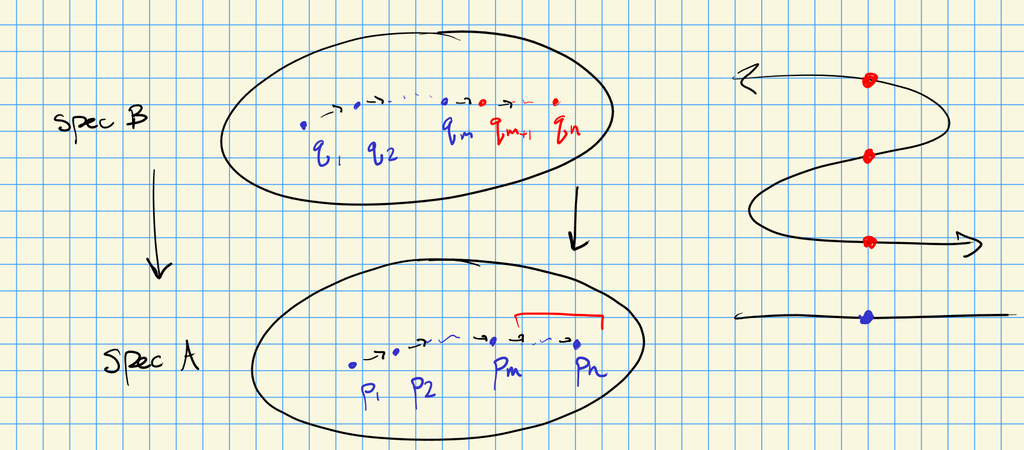

Consider $k[x]\hookrightarrow k[x,y]/\left\langle{y^2-x}\right\rangle$ over $\operatorname{ch}k = 0$ and $k= { \mkern 1.5mu\overline{\mkern-1.5muk\mkern-1.5mu}\mkern 1.5mu }$. Take $p=\left\langle{x-2}\right\rangle$ and $q = \left\langle{y-\sqrt 2}\right\rangle$ or $\left\langle{y+\sqrt 2}\right\rangle$ extend $p$.

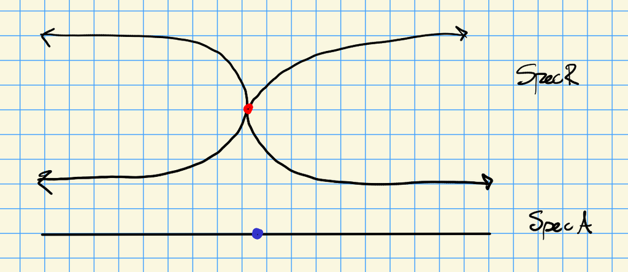

Similarly, take ${\mathbb{Z}}\hookrightarrow{\mathbb{Z}}[i]$ and consider how primes lift (see inert, split, ramified).

For $A \subseteq B$, say $A$ is **integrally closed in $B$** iff $A$ contains every element of $B$ which is integral over $A$.

$k[x] \subseteq k[x,y]$ is integrally closed, but $k[x] \subseteq k[x,y]/\left\langle{y^2-x}\right\rangle$ is not.

For $A\leq B\in \mathsf{IntDom}$ with $A$ integrally closed in $\operatorname{ff}(A)$ and $B$ integral over $A$. If
$$\begin{align*}
p_1 &\supseteq p_2 \supseteq\cdots \supseteq p_n \in \operatorname{Spec}A \\
q_1 &\supseteq q_2 \supseteq\cdots \supseteq q_m \in \operatorname{Spec}B \\
\end{align*}
with \(q_i \cap A = p_i\), then there exist \(q_m \supseteq q_{m+1} \supseteq\cdots \supseteq q_{n+1} \supseteq q_n\) with \(q_i \cap A = p_i\).$$

See A&M, similar to proof of going up.

Idea: closed under *generization* (opposite of specialization, given $x$ finding a point $y$ with $x\in { \operatorname{cl}} y$), so the geometric map is almost open.

Being integrally closed corresponds to a variety being **normal** and is a smoothness condition.

Use $k[x,y]/\left\langle{y^2-x^3}\right\rangle \cong k[x^2, x^3] \hookrightarrow k[x,y]$ to construct a counterexample to the going down theorem when $A \hookrightarrow\operatorname{ff}(A)$ is *not* integrally closed.

## 14.2 Local Properties

On local properties: for $M\in {\mathsf{R}{\hbox{-}}\mathsf{Mod}}^{{\mathrm{fg}}, { \mathrm{Noeth} }}$, a HW problem shows if $p\in \operatorname{Spec}A$ and $M \left[ { \scriptstyle { {p}^{-1}} } \right] = 0$ then $M \left[ { \scriptstyle { {f}^{-1}} } \right] = 0$ for some $f$. This says that the property of being zero extends:

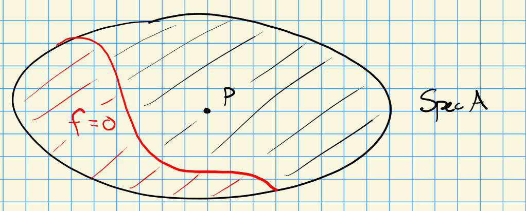

A property $Q$ is **local** iff given $M\in {\mathsf{A}{\hbox{-}}\mathsf{Mod}}$, TFAE:

- $Q$ holds for $M$
- $Q$ holds for $M \left[ { \scriptstyle { {f_i}^{-1}} } \right]$ for every $\left\{{f_i}\right\}$ with $\left\langle{\left\{{f_i}\right\}}\right\rangle = \left\langle{1}\right\rangle$.

Local properties can be checked on an open cover of $\operatorname{Spec}A$, and ${\mathsf{A}{\hbox{-}}\mathsf{Mod}}$ corresponds to ${\mathsf{QCoh}}(\operatorname{Spec}A)$.

One can always take the set $\left\{{f_i}\right\}$ to be finite since if such a collection generates the unit ideal, there is some finite sum $\sum a_i f_i = 1$. One can also reformulate the second condition as follows: for each $p\in \operatorname{Spec}A$, there exists some $f_p \not\in p$ such that every $M \left[ { \scriptstyle { {f_p}^{-1}} } \right]$ satisfies $Q$. $\implies$: Check that $\left\langle{\left\{{f_p}\right\}}\right\rangle = \left\langle{1}\right\rangle$; if not then there exists some $m\in \operatorname{mSpec}A$ with $\left\{{f_p}\right\} \subseteq m$ which is maximal and hence prime.

$\impliedby$: The claim is that given $p$ there exist $f_i\not\in p$. If not, $\left\{{f_i}\right\} \subseteq p$ and $1\in p$.

If $\left\langle{\left\{{f_i}\right\}}\right\rangle = 1$ then $\operatorname{Spec}A \left[ { \scriptstyle { {f_i}^{-1}} } \right] = \operatorname{Spec}A\setminus V(f_i) \subseteq \operatorname{Spec}A$ is an open cover of $\operatorname{Spec}A$. Thus $\operatorname{Spec}A$ is quasicompact for any ring $A$.

Some local properties:

- Being zero
- Being injective/surjective/bijective
- Being finitely generated (and projective)
- Being flat

# 15 Tuesday, March 01

A property is *local* on $A$ if it can be checked on an affine open cover of $\operatorname{Spec}A$. Note that e.g. ${\mathbb{A}}^2_{/ {k}}$ is affine but $\operatorname{Spec}k[x,y]/\left\langle{x,y}\right\rangle \cong{\mathbb{A}}^2_{/ {k}} \setminus\left\{{0}\right\}$ is not an affine open subset.

Show that the property of being zero is local.

> Hint: $M_{f_i} = 0 \implies$ for every $m\in M$ there is an $n_i$ with $f_i^{n_i} m = 0$, write $\sum a_i f_i = 1$, and consider $(\sum a_i f_i)^N m$ for $N\gg 1$.

Show that being injective/surjective/bijective is local.

> Hint: localization is exact, so take the SES $0\to \ker g \to M \xrightarrow{g} N\to \operatorname{coker}g\to 0$.

Show that being finitely generated is local.

> Hint: tensor a presentation. For the other direction, take generators $M_{f_i} = \left\langle{{x_{i1} \over a_{i1}}, {x_{i2} \over a_{i2}},\cdots, {x_{in} \over a_{in}} }\right\rangle$ for $\left\{{f_1,\cdots, f_m}\right\}$, where without loss of generality $a_{ij} = 1$, and take $\left\{{x_{ij}}\right\}$ and check surjectivity locally.

Show that flatness is local, i.e. if $M\in {\mathsf{A}{\hbox{-}}\mathsf{Mod}}^\flat$ then $M_f\in {\mathsf{A_f}{\hbox{-}}\mathsf{Mod}}^\flat$.

> Hint: to show $M_f$ is flat assuming $M$ is flat, show that $\operatorname{Tor}^{A_f}_i(A_f/a, M_f) = 0$ by taking ${ {P}^{\scriptscriptstyle \bullet}} \twoheadrightarrow M$ and ${ {P}^{\scriptscriptstyle \bullet}} _f \twoheadrightarrow M_f$. Then compute
> $$\begin{align*}
> \operatorname{Tor}_1(M_f, A_f/a)
> &= H_1( { {P}^{\scriptscriptstyle \bullet}} _f \otimes A_f/a) \\
> &= H_1( { {P}^{\scriptscriptstyle \bullet}} \otimes A/a' \otimes A_f) \\
> &= H_1( { {P}^{\scriptscriptstyle \bullet}} \otimes A/a') \otimes A_f \\
> &= 0 \otimes A_f = 0
> ,\end{align*}
> using that localization is exact and thus commutes with taking homology. In the other direction, show that for \(0\to A \xrightarrow{f} B\to C\to 0\) leads to \(A\otimes M \xrightarrow{\tilde f} B\otimes M\), and injectivity can be checked locally.$$

Define the **support** of $M$ as $\mathop{\mathrm{supp}}(M) \mathrel{\vcenter{:}}=\left\{{p\in \operatorname{Spec}A{~\mathrel{\Big\vert}~}M_p\neq 0}\right\}$, thought of as points where “functions on $A$” defined by $M$ do not vanish.

Show that if $M\in {\mathsf{A}{\hbox{-}}\mathsf{Mod}}^{\mathrm{fg}}$ then $\mathop{\mathrm{supp}}M = V(\operatorname{Ann}_A(M))$ where $\operatorname{Ann}_A(M) \mathrel{\vcenter{:}}=\left\{{a\in A{~\mathrel{\Big\vert}~}am=0 \, \forall m\in M}\right\}$.

Show that for $M\in {\mathsf{A}{\hbox{-}}\mathsf{Mod}}^{\mathrm{fg}}$ with $A$ Noetherian, $M=0 \iff \mathop{\mathrm{supp}}M = 0$.

Modules give sheaves over $\operatorname{Spec}A$, and the following theorem is a special case of faithfully flat descent:

If $M\in {\mathsf{A}{\hbox{-}}\mathsf{Mod}}^{\mathrm{fg}}$ and $\left\{{f_i}\right\}$ is a finite generating set, then the following sequence is exact:
$$\begin{align*}
0 \to M \to \bigoplus_{f_i} M_{f_i} &\to \bigoplus M_{f_i f_i} \\
x\in M_{f_i} &\mapsto {\left[ {\cdots, {x\over f_i f_j}, \cdots, -{x\over f_j f_i}, \cdots } \right]}
.\end{align*}
with the positive sign in the \(i\)th component and the negative in the \(j\)th.$$

Prove this: check injectivity locally, and use that localization commutes with direct sums. Note that essentially the same proof goes through for faithfully flat descent.

If $M\in {\mathsf{A}{\hbox{-}}\mathsf{Mod}}^{\flat, {\mathrm{fg}}}$ for $A$ Noetherian, then $M$ is locally free, i.e. there exist $f_i$ generating the unit ideal with $M_{f_i}$ free for all $i$.

Philosophy: reduce to local case.

1. For $A$ local: finitely-generated flat flat modules over a Noetherian *local* ring is free.
2. Hence $M_p$ is free over $A_p$ for all $p\in \operatorname{Spec}A$.
3. Spreading out: by the HW, there exist $f_i^p$ not in $p$ such that $M_{f_1^p \cdots f_\ell^p}$ is free and equals $M_{f^p}$.
4. The finite collection $\left\{{P^*}\right\}$ generated the unit ideal.

Next: Artinian, local, complete local rings, DVRs, etc – the building blocks of the theory of local rings!

# 16 Thursday, March 03

Next topic: Artin rings. The general way we reduce the study of arbitrary rings:

[figure not shown]

> Link to Diagram
- Recall that Artin rings are defined by the DCC condition on ideals.
- The **length** of a module is the maximal length of a strictly increasing filtration.

Show the following:

- ${\mathbb{C}}[t]/\left\langle{t^n}\right\rangle$ is Artin.
- $C_{p^n}$ is Artin.
- ${\mathbb{Z}}$ is Noetherian but not Artin.
- Any finite product of fields is Artin.
- An Artin domain is a field.
- Prime implies maximal in any Artin ring.

  > Hint: quotient by the prime, and use that any element $a$ satisfies $a^n = ba^{n+1}$ for some $n$ and $b$ to produce an inverse.
- $\operatorname{Spec}A = \left\{{{\operatorname{pt}}}\right\}$ for a local Artin ring.
- Artin rings $A$ have finite length in ${\mathsf{A}{\hbox{-}}\mathsf{Mod}}$.
- Quotients of Artin rings by their Jacobson radicals are products of fields.
- $\operatorname{Spec}A = \displaystyle\coprod_i \left\{{{\operatorname{pt}}_i}\right\}$ is a disjoint union of points, and is Hausdorff.
  - The only Noetherian rings with Hausdorff spectra are Artin.

Artin rings are Noetherian.

Use that

- Any module has a maximal proper submodule.
- Choose ${\mathfrak{a}}_i \subseteq A$ simple, so $A/{\mathfrak{a}}_i$ is Artinian, to produce an increasing chain $0 \subseteq {\mathfrak{a}}_1 \subseteq {\mathfrak{a}}_2 \cdots$ where ${\mathfrak{a}}_i/{\mathfrak{a}}_{i+1}$ is simple for all $i$.
- Enumerate maximal ideals ${\mathfrak{m}}_i$ and produce a chain ${\mathfrak{m}}_1 \supseteq{\mathfrak{m}}_2 \supseteq\cdots$ and take colon ideals.
- Reduce to this case by showing every chain refines.

Steps:

- Make a descending filtration with semisimple associated graded, whose filtration is finite.
- Use Jordan-Holder, every such sequence has the same length.
- Refine an arbitrary filtration to one in which the quotients are simple.

${\sharp}\operatorname{mSpec}A < \infty$ for $A\in \mathsf{Art}\mathsf{CRing}$.

Hints:

- If not, take a decreasing chain of ${\mathfrak{m}}_1 \supseteq{\mathfrak{m}}_1{\mathfrak{m}}_2 \cdots$, stabilize, use that the ${\mathfrak{m}}_i$ are finitely-generated and apply Nakayama.
- If $I$ is defined as the product at the minimal stabilized step, $I \subseteq {J ({A}) }$.
- Without loss of generality, assume ${J ({A}) } = 0$, so $I=0$ since $\operatorname{mSpec}A/{J ({A}) } \cong \operatorname{mSpec}A$.
- $A/{\mathfrak{m}}_1\cdots {\mathfrak{m}}_n = \prod A/{\mathfrak{m}}_i$ is a product of fields
- Corollary: $n> N$, ${\mathfrak{m}}_N$ will have empty support.

# 17 Tuesday, March 15

## 17.1 Artin Rings

Last time: $A/{J ({A}) }$ is a product of Artin local rings.

Show that if $A$ is Artin local, then ${\mathfrak{m}}_A^n = 0$ for some $n$.

> Hint: use that $\left\{{{\mathfrak{m}}^k}\right\}_{k\geq 0}$ stabilizes, so ${\mathfrak{m}}^n/{\mathfrak{m}}^{n+1} \cong {\mathfrak{m}}^n/{\mathfrak{m}}{\mathfrak{m}}^{n} = 0$ so ${\mathfrak{m}}^n=0$ since $A$ is Noetherian.

Show that if $A$ is an Artin local ring that is finitely generated over an algebraically closed field $k$. Then $A$ is a quotient of $k[x_1, \cdots, x_{n}]/\left\langle{x_1,\cdots,x_n}\right\rangle^N$ for some $n$ and $N$.

Hint: use that ${\mathfrak{m}}$ is finitely generated, construct a surjection $k[x_1, \cdots, x_{n}]\to A$, and show $I_{N} \mathrel{\vcenter{:}}=\left\langle{x_1,\cdots, x_n}\right\rangle^N$ is in the kernel. Also use the corollary of the Nullstellensatz (EEKS) that finite extensions of $k$ which are fields are necessarily $k$ itself. Apply the snake lemma:

[figure not shown]

> Link to Diagram

This shows surjectivity, and $\left\langle{x_1,\cdots, x_n}\right\rangle^N$ being in the kernel follows from the previous proposition.

## 17.2 DVRs

Recall that a Noetherian local domain $A$ is a DVR if ${\mathfrak{m}}\neq 0$ is principal. Show that $\dim_k {\mathfrak{m}}/{\mathfrak{m}}^2 = 1$ for $k=A/{\mathfrak{m}}$.

> Hint: use Nakayama to bound the dimension by 1.

Examples of DVRs:

- $k{\left[\left[ t \right]\right] }$
- ${ {\mathbb{Z}}_{\widehat{p}} }$
- ${\mathbb{Z}}_{(p)} = {\mathbb{Z}} { \left[ \scriptstyle {\left\{{ q^{-1}{~\mathrel{\Big\vert}~}q\neq p }\right\}} \right] }$.

A non-example: $k{\left[\left[ x,y \right]\right] }$.

Show that if $A$ is a DVR with uniformizer $\pi$ and $a\in A\setminus\left\{{0}\right\}$, then there is a unique $n\in {\mathbb{Z}}_{\geq 0}$ such that $a = \pi^n a_u$ with $a_u$ a unit.

> Hint: for existence, set $N\mathrel{\vcenter{:}}=\max \left\{{N{~\mathrel{\Big\vert}~}a\in \left\langle{\pi^N}\right\rangle}\right\}$ which exists because $\cap_N \left\langle{\pi^N}\right\rangle = 0$. Use that $\pi I = I \implies I=0$ by Nakayama, to write $a = \pi^n a_0$, and if $a_0$ is not a unit then $a_0\in\left\langle{\pi}\right\rangle$ contradicting maximality.

If $A$ is a DVR, $\operatorname{Id}(A) = \left\{{\left\langle{0}\right\rangle, \left\langle{\pi^n}\right\rangle }\right\}_{n\geq 0}$ and $\operatorname{Spec}A = \left\{{\left\langle{\pi}\right\rangle, \left\langle{0}\right\rangle}\right\}$. This follows from writing
$$\begin{align*}
I = \left\langle{a_1,\cdots, a_N}\right\rangle = \left\langle{\pi^{n_1} b_1,\cdots, \pi^{n_N} b_N }\right\rangle = \left\langle{\pi^m}\right\rangle,\qquad m\mathrel{\vcenter{:}}=\min\left\{{n_j}\right\}_{j\leq N}
.\end{align*}$$

Show that DVRs $A$ biject with fields $K$ equipped with a valuation $v: K\to {\mathbb{Z}}\cup\left\{{\infty}\right\}$ satisfying:

- $v(a+b) \geq \min( v(a), v(b) )$,
- $v(ab) = v(a) + v(b)$,
- $v(a) =\infty \iff a=0$,
- $v(K^{\times}) \neq {\mathbb{Z}}$.

> Hint: for $A\in\mathsf{DVR}$, set $K = \operatorname{ff}(A)$ and $v(a/b)\mathrel{\vcenter{:}}= v(a)-v(b)$ where $v(\pi^n a_0) = n$. Given $(K, v)$, set $A = \left\{{x\in K {~\mathrel{\Big\vert}~}v(x)\geq 0}\right\}$ with ${\mathfrak{m}}= \left\{{v(x) > 0}\right\}$, showing ${\mathfrak{m}}^c \subseteq A^{\times}$ and ${\mathfrak{m}}$ is generated by any $x$ with $v(x) = 1$?

## 17.3 Classifying finitely-generated modules over a DVR

Recall that $M\in{\mathsf{A}{\hbox{-}}\mathsf{Mod}}$ is torsionfree iff $\operatorname{Ann}_A(M) \mathrel{\vcenter{:}}=\left\{{a\in A{~\mathrel{\Big\vert}~}am=0}\right\}$ contains only zero divisors iff $M \xrightarrow{\times a} M$ is injective for all nonzero $a\in A$.

Show that if $A\in \mathsf{CRing}^{{ \mathrm{Noeth} }}$ and $M\in {\mathsf{A}{\hbox{-}}\mathsf{Mod}}^{\mathrm{fg}}$ then $0\to M_{\operatorname{tors}}\to M\to M'\to 0$ is a SES where $M'$ is torsionfree, and moreover there exists some $a\in A$ such that $a M_{\operatorname{tors}}= 0$.

> Hint: for the latter statement, use that $M_{\operatorname{tors}}$ is finitely-generated and take a product of annihilators of generators. For the former, take $a\in \operatorname{Ann}_A(\tilde m)$ for some $\tilde m\in M'$, lift to $m\in M$ and show $am\in M_{\operatorname{tors}}$ for some $a$.

Show that if $A$ is a PID, then $M\in{\mathsf{A}{\hbox{-}}\mathsf{Mod}}$ is flat iff $M$ is torsionfree.

> Hint: use $A \xrightarrow{\times a} A$ and apply $({-}) \otimes_A M$. For the reverse, show $\operatorname{Tor}^1(M, A/I) = 0$ for any ideal in $A$ and compute using the projective resolution $0\to A \xrightarrow{\times a} A \to A/\left\langle{a}\right\rangle \to 0$. Note that $H_1(M \xrightarrow{\times a} M ) = \ker(M \xrightarrow{\times a} M) = 0$ since $M$ is torsionfree.

Show that for $A$ a DVR and $M\in {\mathsf{A}{\hbox{-}}\mathsf{Mod}}^{\mathrm{fg}}$, then $M$ torsionfree implies $M$ is free.

> Hint: torsionfree $\implies$ flat $\implies$ free for finitely-generated Noetherian local rings.

Show that if $M \in {\mathsf{A}{\hbox{-}}\mathsf{Mod}}^{\mathrm{fg}}$ for $A$ a DVR then $M \cong M_{\operatorname{tors}}\oplus A^n$ for some $n$.

> Hint: use that the SES involving $M_{\operatorname{tors}}\to M$ splits.

Show that any finitely-generated torsion module over $A$ is isomorphic to $\bigoplus_i A/\pi^{n_i} A$. Use this to classify all finitely-generated modules over $k{\left[\left[ t \right]\right] }$.

# 18 Tuesday, March 22

## 18.1 Classification of finitely-generated modules over a Dedekind domain

A ring $A$ is a **Dedekind domain** iff

- $A\in{ \mathrm{Noeth} }\mathsf{Domain}, \operatorname{krulldim}A = 1$,
- The local rings $A_p$ are DVRs for all $p\in \operatorname{mSpec}A$.

If $M\in {\mathsf{A}{\hbox{-}}\mathsf{Mod}}, A\in \mathsf{Dedekind}\mathsf{Domain}$, then
$$\begin{align*}
M\underset{{\mathsf{A}{\hbox{-}}\mathsf{Mod}}}{\cong} T \oplus F \mathrel{\vcenter{:}}=\qty{ \bigoplus (A/{\mathfrak{p}}_i)^{n_i} } \oplus \qty{ \bigoplus {\mathcal{L}}_i }
\end{align*}
where \({\mathcal{L}}_i \in {\mathsf{A}{\hbox{-}}\mathsf{Mod}}^{{\mathsf{locfree}}, \operatorname{rank}=1}\) (and are in particular torsionfree) and the \(A/{\mathfrak{p}}_i\) are torsion.$$

Show that if $p\in \operatorname{Spec}A$ then $M_p \cong A_p^m$ where $m = \operatorname{rank}M$.

> Hint: use that $M_p \oplus \operatorname{ff}(A_p) = \operatorname{ff}(A)^n = \operatorname{ff}(A)^n$

Show that for $A$ a Dedekind domain and $M\in {\mathsf{A}{\hbox{-}}\mathsf{Mod}}^{\mathrm{fg}}$, TFAE:

- $M\in {\mathsf{A}{\hbox{-}}\mathsf{Mod}}^\flat$
- $M\in {\mathsf{A}{\hbox{-}}\mathsf{Mod}}(\mathop{\mathrm{proj}})$
- $M\in {\mathsf{A}{\hbox{-}}\mathsf{Mod}}^{{\mathsf{locfree}}}$
- $M$ is torsionfree

Conclude that the following SES splits:
$$\begin{align*}
0\to M_{\operatorname{tors}}\to M \to M_{{\operatorname{tors}}{\mathrm{free}}} \to 0
.\end{align*}$$

> Hint: the first three already hold for Noetherian domains. To show flat $\implies$ torsionfree, that $0\to A \xrightarrow{\cdot a} A \to A/\left\langle{a}\right\rangle \to 0$ for $a\in \mathsf{Tors}(M)$ and tensor with $M$. For the converse, show $M_p$ is flat for all $p$ and that $A_p$ is a DVR – if ${a\over s'}{m\over s} = 0 \implies \tilde s' s am = 0$ for some $\tilde s$, then $m$ is torsion.

Note that torsionfree $\implies$ flat fails for most rings!

Show that if $M\in {\mathsf{A}{\hbox{-}}\mathsf{Mod}}^{\mathrm{fg}}$ is torsion over a Dedekind domain $A$ then $M \cong \bigoplus _{i} (A/p_i^{n_i})^{m_i}$.

> Hint: use that $\mathop{\mathrm{supp}}M$ is finite to produce a map $M\to \bigoplus _i M_{p_i}$ and show it is locally an isomorphism since $(M_{p})_q = M_q$ when $q\neq p$. Also use that $M_p = \bigoplus _j A_p/p^{i_j} \cong \oplus_j A/p^{i_j}$.

Show that for $M\in {\mathsf{A}{\hbox{-}}\mathsf{Mod}}^{\mathrm{fg}}$ torsionfree over $A$ a Dedekind domain, there is a (not necessarily unique) decomposition $M \cong \bigoplus _i {\mathcal{L}}_i$ with ${\mathcal{L}}_i$ locally free of rank 1.

> Induct on rank, where it’s ETS there exists an ${\mathcal{L}}$ where $M/{\mathcal{L}}_i$ is torsionfree since $0\to {\mathcal{L}}\to M\to M/{\mathcal{L}}_i\to 0$ splits (tensor to fraction field). To find such an ${\mathcal{L}}$, take any $m\neq 0$ and take ${\mathcal{L}}$ to be the preimage of $(M/\left\langle{m}\right\rangle)_{\operatorname{tors}}$ under $M \to M/\left\langle{m}\right\rangle$; then ${\mathcal{M}}/{\mathcal{L}}$ will be torsionfree and is rank 1 since ${\mathcal{L}}\otimes\operatorname{ff}(A) \cong \left\langle{m}\right\rangle\otimes\operatorname{ff}(A)$.

## 18.2 Classification of locally free rank 1 modules over a Dedekind domain

Show that if $I{~\trianglelefteq~}A$ is nonzero for $A$ a Dedekind domain, then $I$ is locally free of rank 1.

> Hint: show that $I_p\leq A_p$ is nonzero, so $I_p = \left\langle{\pi^n}\right\rangle$ for $\pi$ a uniformizer of $A_p$.

A module $M\in {\mathsf{A}{\hbox{-}}\mathsf{Mod}}$ is **invertible** iff $M$ is locally free of rank 1. Equivalently, defining $M {}^{ \vee }\mathrel{\vcenter{:}}={\mathsf{A}{\hbox{-}}\mathsf{Mod}}(M, A)$ there is an evaluation isomorphism $M\otimes_A M {}^{ \vee } { \, \xrightarrow{\sim}\, }A$. Define
$$\begin{align*}
{\operatorname{Pic}}(A) \mathrel{\vcenter{:}}=({\mathsf{A}{\hbox{-}}\mathsf{Mod}}, \otimes_A)/\cong
.\end{align*}
Note that for \(A = {\mathcal{O}}_K, K\in \mathsf{Field}_{/ {{\mathbb{Q}}}}\),
\begin{align*}
{\operatorname{Pic}}(A) \cong { \operatorname{Cl}} (K)
.\end{align*}$$

For $A$ a Dedekind domain, a **divisor** is a formal linear combination
$$\begin{align*}
D = \sum_{{\mathfrak{p}}\neq 0 \in \operatorname{Spec}A} n_p {\mathfrak{p}}\in \mathsf{Free}_{{\mathbb{Z}{\hbox{-}}\mathsf{Mod}}}(\operatorname{Spec}A)
.\end{align*}
such that \(n_p = 0\) for almost all \(p\). These form a group \(\operatorname{Div}(A)\). A divisor \(D\) is effective iff \(n_p\geq 0\) for all \(p\), yielding a submonoid \(\operatorname{Div}^+(A)\) of effective divisors.$$

More generally, this will be a sum over height 1 primes.

Show that there is a natural bijection
$$\begin{align*}
\operatorname{Div}^+(A) &\rightleftharpoons\operatorname{Id}(A)\setminus\left\{{0}\right\}\\
\sum n_p p &\rightleftharpoons\prod p^{n_p}
.\end{align*}$$

> Hint: if $\operatorname{krulldim}A = 1$, use that $\operatorname{Id}(A)\cong \left\{{I_p {~\trianglelefteq~}A_p}\right\}_{p\in P}$ where $I_p = A_p$ for almost all $p$, and each $I_p \cong \left\langle{\pi_p^{n_p}}\right\rangle$.

Show that if ${\mathcal{L}}$ is invertible then ${\mathcal{L}} {}^{ \vee }$ is invertible.

> Hint: show ${\mathcal{L}} {}^{ \vee }$ is locally free of rank 1, using ${\mathcal{L}}_p {}^{ \vee } { \, \xrightarrow{\sim}\, }{\mathsf{A}{\hbox{-}}\mathsf{Mod}}({\mathcal{L}}, A)_p { \, \xrightarrow{\sim}\, }{\mathsf{A_p}{\hbox{-}}\mathsf{Mod}}({\mathcal{L}}_p, A_p)$ by post-composing with localization. Then check ${\mathcal{L}}\otimes{\mathsf{A}{\hbox{-}}\mathsf{Mod}}({\mathcal{L}}, A)\to A$ where $(n, f) \mapsto f(n)$ is an isomorphism by checking locally where everything is free.

Write $D\in \operatorname{Div}(A)$ as $D = D^+ - D^-$ where $D^{\pm} \in \operatorname{Div}^+(A)$ are effective. There is a SES

[figure not shown]

> Link to Diagram

This is generally far from injective, and will instead biject with *fractional ideals*:

For $A \in \mathsf{Dedekind}$, a **fractional ideal** is a nonzero $A{\hbox{-}}$submodule ${\mathcal{L}}\leq A$ where ${\mathcal{L}}\in {\mathsf{A}{\hbox{-}}\mathsf{Mod}}^{\mathrm{fg}}$.

- $I{~\trianglelefteq~}A$ or $I{~\trianglelefteq~}\operatorname{ff}(A)$ any ideal
- ${1\over a}I{~\trianglelefteq~}\operatorname{ff}(A)$.

Show that any fractional ideal is invertible.

> Hint: use that any such $I$ is torsionfree since it’s a subset of $\operatorname{ff}(A)$, and ${\mathcal{L}}\otimes_A \operatorname{ff}(A) \cong \operatorname{ff}(A)$ implies rank 1.

# 19 Tuesday, March 29

Last time: proving the following theorem.

If $A\in{ \mathrm{Noeth} }{\mathsf{loc}}\mathsf{Domain}$ with $\operatorname{krulldim}A = 1$, then $A\in\mathsf{DVR}\iff A$ is integrally closed.

Last time: DVR $\implies$ integrally closed.

$\impliedby$: It suffices to show that the maximal ideal is principal. Let $a\in {\mathfrak{m}}\setminus\left\{{0}\right\}$, then $A/\left\langle{a}\right\rangle$ is Artinian (which is true here for any quotient) and thus ${\mathfrak{m}}^k = 0$ in $A/\left\langle{a}\right\rangle$ for some $k$ (chosen minimally), so ${\mathfrak{m}}^k \in \left\langle{a}\right\rangle$. By minimality, pick $b\in {\mathfrak{m}}^{k-1}\setminus\left\langle{a}\right\rangle$ – the claim is that $a/b$ generates ${\mathfrak{m}}$. First, $\qty{b\over a}{\mathfrak{m}}{~\trianglelefteq~}A$ since $bm\in {\mathfrak{m}}^k \subseteq \left\langle{a}\right\rangle$. It’s ETS $\qty{b\over a} m$ is not contained in ${\mathfrak{m}}$ – given this, $\qty{b\over a}{\mathfrak{m}}= A$ by maximality and this implies ${\mathfrak{m}}= {b\over a} A$.

Why this last claim is true: the map $x\mapsto {a\over b}x: {\mathfrak{m}}\to {\mathfrak{m}}$ is annihilated by some polynomial with coefficients in $A$ by Cayley-Hamilton, and by integral closedness this implies $a/b\in A$. Then $a/b\in {\mathfrak{m}}$, a contradiction since $a/b$ is a unit and ${\mathfrak{m}}$ is proper. $\contradiction$

If $A\in{ \mathrm{Noeth} }\mathsf{Domain}$ (not necessarily local) $\operatorname{krulldim}A = 1$, then $A\in\mathsf{Dedekind}\mathsf{Domain}\iff A$ is integrally closed.

$A$ Dedekind means all local rings are DVRs, so it’s ETS $A$ is integrally closed iff $A \left[ { \scriptstyle { {p}^{-1}} } \right]$ is integrally closed (since we can apply the last theorem to $A \left[ { \scriptstyle { {p}^{-1}} } \right]$).

Let $A \subseteq B$ be an inclusion of rings and let $\operatorname{cl}^{\mathrm{int}} _B A$ be the integral closure of $A$ in $B$. If $S \subseteq A$ is a multiplicative subset, then
$$\begin{align*}
\operatorname{cl}^{\mathrm{int}} _B (A \left[ { \scriptstyle { {S}^{-1}} } \right]) \cong ( \operatorname{cl}^{\mathrm{int}} _B A) \left[ { \scriptstyle { {S}^{-1}} } \right]
.\end{align*}$$

$\supseteq$: Take $b\in A_{\mathrm{int}}$ and $s\in S$, we then WTS $b/s$ satisfies a monic polynomial over $A \left[ { \scriptstyle { {S}^{-1}} } \right]$. If $f(b) = b^n + a_1 b^{n-1} + \cdots = 0$, note that $s^nf(b) = 0$ and is of the form $\qty{b\over s}^n + sa_1{b\over s}^{n-1} + \cdots$ is a polynomial with coefficients in $A \left[ { \scriptstyle { {S}^{-1}} } \right]$.

$\subseteq$: Let $b/s$ in the LHS, so $\qty{b\over s}^n + {a_1\over s_1}\qty{b\over s}^{n-1} + \cdots = 0$. Multiply through by $s^n\qty{\prod s_i}^n$ to get $\qty{\prod s_i}^n b^n + a_1 s' b^{n-1} \qty{\prod s_i}^{n-1} + \cdots$ by absorbing some factors into the coefficient $s'$, so $b\prod s_i$ satisfies a monic polynomial.

By the lemma, $A$ integrally closed $\implies A \left[ { \scriptstyle { {p}^{-1}} } \right]$ is integrally closed because $(A \left[ { \scriptstyle { {p}^{-1}} } \right])_{\mathrm{int} } = (A_{\mathrm{int}}) \left[ { \scriptstyle { {p}^{-1}} } \right] = A \left[ { \scriptstyle { {p}^{-1}} } \right]$. Suppose that $A \left[ { \scriptstyle { {p}^{-1}} } \right]$ is integrally closed. There is a map $A\to A_{\mathrm{int}}$ which we want to show is an isomorphism. Check locally: $A \left[ { \scriptstyle { {p}^{-1}} } \right] \to (A_{\mathrm{int}}) \left[ { \scriptstyle { {p}^{-1}} } \right] \to (A \left[ { \scriptstyle { {p}^{-1}} } \right])_{\mathrm{int}} = A{ \scriptsize {}_{ \left[ { \scriptstyle { {p}^{-1}} } \right] } }$.

Let $A\in\mathsf{Dedekind}$ with $K = \operatorname{ff}(A)$ and let $K'/K$ be a finite separable extension. Then $\operatorname{cl}^{\mathrm{int}} _{K'} A\in\mathsf{Dedekind}$ is Dedekind.

> Note that in characteristic zero, finite extensions are automatically separable.
- For $K/{\mathbb{Q}}$ a finite separable extension, then $\operatorname{cl}^{\mathrm{int}} _K {\mathbb{Z}}$ is Dedekind.
- For $L/k[t]$ finite separable, $\operatorname{cl}^{\mathrm{int}} _{L} k[t]$ is Dedekind.

Let $A' \mathrel{\vcenter{:}}= \operatorname{cl}^{\mathrm{int}} _{K'} A$, then $A'\in {\mathsf{A}{\hbox{-}}\mathsf{Mod}}^{\mathrm{fg}}$.

- By the Hilbert basis theorem, $A'$ is Noetherian
- $A'$ is a domain since $A' \subseteq K'$
- $A'$ is integrally closed: STS satisfying a monic polynomial over $A'$ implies satisfying a monic polynomial over $A$. To check if $b\in K'$ is integral, one needs that $A'[b]\in {\mathsf{A'}{\hbox{-}}\mathsf{Mod}}$ is finite, which implies $A'[b] \in {\mathsf{A}{\hbox{-}}\mathsf{Mod}}$ is finite. This is true because $A[b] \leq A'[b]$ is a submodule and $A$ is Noetherian, so $b$ is integral over $A$.
- $\operatorname{krulldim}A' = 1$: STS $\operatorname{Spec}A' \subseteq \operatorname{mSpec}A'$. Let $p$ be prime in $A$ and let $\tilde p \mathrel{\vcenter{:}}= p \cap A \in \operatorname{Id}(A)$. There is a finitely-generated extension $A/\tilde p \leq A'/p$, and it’s ETS $A/\tilde p\in \mathsf{Field}$ by EEKS (finitely-generated ring extensions of fields are fields). ETS $\tilde p \in \operatorname{mSpec}A$ – consider $\operatorname{Spec}A' \xrightarrow{\pi} \operatorname{Spec}A$, we WTS $\pi^{-1}(\left\langle{0}\right\rangle) = \left\{{\left\langle{0}\right\rangle}\right\}$. Fact: $\pi^{-1}(\left\langle{0}\right\rangle) = \operatorname{Spec}A' \left[ { \scriptstyle { {A^{\times}}^{-1}} } \right] = \operatorname{Spec}(A' \otimes K) = \operatorname{Spec}(K')$. This uses the fact that $A'\otimes_A K { \, \xrightarrow{\sim}\, }K'$, which can be checked locally on DVRs.

Assume $\operatorname{ch}K = 0$. We know that $K'/K$ is finite, so pick a basis $\left\{{e_i}\right\}$. We can scale the $e_i$ by elements of $A$ so that they are in $A'$ – use that $K' = A'\otimes_A R$, so $e_i = \sum a_i'/s_i$ and one can scale by the $s_i$.

There is nondegenerate pairing ${\left\langle {x},~{y} \right\rangle}\mathrel{\vcenter{:}}=\operatorname{Tr}_{K'/K}(xy)$ where $\operatorname{Tr}(z)$ is the trace of the $K{\hbox{-}}$linear map $K' \xrightarrow{\cdot z} K'$. Why this is nondegenerate: use the separability assumption. Given $x\in K'\setminus\left\{{0}\right\}$, produce a $y$ such that ${\left\langle {x},~{y} \right\rangle}\neq 0$ by setting $y=x^{-1}$ (noting that this won’t work in characteristic $p$).

Use this to define a dual basis $\left\{{f_i}\right\}$ such that ${\left\langle {e_i},~{f_j} \right\rangle} = \delta_{ij}$. We can then express $x = \sum_{1\leq i\leq n} {\left\langle {x},~{f_i} \right\rangle} e_i$, and it’s ETS that if $x\in A'$ then ${\left\langle {x},~{f_i} \right\rangle}\in A$. For $x\in A'$, we have $\operatorname{Tr}(x)\in A$, e.g. because it is a sum of Galois conjugates (after passing to a Galois extension), or that $\operatorname{Tr}(x) = \sum r_i$ the roots of a characteristic polynomial with coefficients in $A$. This exhausts the possible factors of the characteristic polynomial.

# 20 Thursday, March 31

Last time: $A\in \mathsf{Dedekind}$ and $M\in {\mathsf{A}{\hbox{-}}\mathsf{Mod}}^{\mathrm{fg}}$ implies $A\cong \bigoplus A/I_i \oplus \bigoplus_{{\mathcal{L}}_i\in {\operatorname{Pic}}(A)} {\mathcal{L}}_i$.

Show that this implies the classification of finitely-generated modules over a PID: $M \cong \bigoplus A/p_i^{n_i} \oplus A^n$.

Sketch:

- PIDs are Dedekind, so ETS ${\operatorname{Pic}}(A) = \left\{{A}\right\}$.
- Use the SES $K^{\times}\xrightarrow{x\mapsto \sum v_p(x) p} \operatorname{Div}A\to {\operatorname{Pic}}A \to 0$, ETS the given map is surjective.
- Reduce: ETS that for $g\in p\in \operatorname{Spec}A$ with $p$ nonzero, there exists an $x\in K^{\times}$ such that $v_p(x) = 1$ and $v_{p'}(x) = 0$ for all $p'\neq p$.
  - If $p = \left\langle{x}\right\rangle$, this works: $v_p(x) = 1$ since this is the maximal $k$ such that $x\in p^k$, but $x\in p^2\implies p=p^2$, contradicting Nakayama. $\contradiction$
  - If $v_{p'}(x) > 0$, then $x\in p'$, $p \subseteq p'$ contradicting maximality of $p$. $\contradiction$

What about rings of dimension $d \geq 2$? E.g. $\dim k[x_1, \cdots, x_{n}]= n$, regarded as functions on ${\mathbb{A}}^n_{/ {k}}$, noting that we haven’t quite defined dimension yet.

Finitely-generated locally free modules over $k[x_1, \cdots, x_{n}]$ are free.

## 20.1 Toward dimension: filtered/graded rings

It is easy to slightly modify this statement to make such a classification impossible!

How many homogeneous polynomials of degree $d$ in $n$ variables are there? Counting the dimension as a $k{\hbox{-}}$vector space is yields ${n+d\choose d} \sim d^n$.

Recall:

- An increasing filtration $\left\{{M_i}\right\}$ of $M\in {\mathsf{A}{\hbox{-}}\mathsf{Mod}}$ satisfies $M_i \subseteq M_{i+1}$ and $\cup_i M_i = M$ and there exists some $i_0$ with $M_{i_k} = 0$ for all $i_k\leq i_0$.
- A module morphism $M \xrightarrow{f} N$ respects filtrations iff $f(M_i) \subseteq N_i$.
- For $N\leq M$ there is an induced filtrations $N_i \mathrel{\vcenter{:}}= M_i \cap N$.
- For $M \xrightarrow[]{f} { \mathrel{\mkern-16mu}\rightarrow }\, Q$ a *surjective* morphism, there is an induced filtration $Q_i \mathrel{\vcenter{:}}= f(M_i)$.
- A **graded abelian group** is a group $M \cong \bigoplus _{i\in {\mathbb{Z}}} M_i$ with $M_i = 0$ for $i\ll 0$. Typical example: $k[x_1, \cdots, x_{n}]= \bigoplus _d k[x_1, \cdots, x_{n}]_d$ is graded by homogeneous degree $d$ parts.
- Passing between filtrations and gradings: given a grading $\oplus_i M_i$, set ${\operatorname{Fil}}^i M = \bigoplus _{k\leq i} M_i$. Given a filtration, take the associated graded $\bigoplus_i M_i/M_{i-1}$.
- Taking the filtration is innocuous and doesn’t change the module, but taking the associated graded does. Example: $M = {\mathbb{Z}}$, take the filtration $\left\langle{0}\right\rangle \subseteq \left\langle{2}\right\rangle \subseteq {\mathbb{Z}}$ whose associated graded is $\left\langle{2}\right\rangle \bigoplus {\mathbb{Z}}/2{\mathbb{Z}}\cong {\mathbb{Z}}\oplus C_2$, which now has torsion.
- A morphism of filtered modules induces a well-defined map on the associated graded modules.

Show that if $f: M\to N$ is a morphism of filtered modules, then ${\mathsf{gr}\,}f$ is injective/surjective $\implies f$ is injective/surjective respectively. Show that the converse is not necessarily true unless $f$ is injective/surjective and the filtrations are induced.

For injectivity, if ${\mathsf{gr}\,}f$ is injective choose $i$ minimally so that $M_i$ intersects $\ker f$, and contradict $i > -\infty$. By minimality, $x \not\in M_{i-1}$ so $\mkern 1.5mu\overline{\mkern-1.5mux\mkern-1.5mu}\mkern 1.5mu\neq 0\in {\mathsf{gr}\,}^i(M) = M_{i} / M_{i-1}$, but ${\mathsf{gr}\,}(f)(\mkern 1.5mu\overline{\mkern-1.5mux\mkern-1.5mu}\mkern 1.5mu) = 0$.

For surjectivity, ETS $f: M_i\to N_i$ is surjective for all $i$. Induct on $i$, using that $M_i = N_i = 0$ for $i \ll 0$. Given $x\in N_i$, take $\mkern 1.5mu\overline{\mkern-1.5mux\mkern-1.5mu}\mkern 1.5mu\in N_i/N_{i-1}$ and lift to $y\in M_i$ such that ${\mathsf{gr}\,}(f)(\mkern 1.5mu\overline{\mkern-1.5muy\mkern-1.5mu}\mkern 1.5mu) = \mkern 1.5mu\overline{\mkern-1.5mux\mkern-1.5mu}\mkern 1.5mu$; take $x-f(y)\in N_{i-1}$.

Definitions:

- A **graded ring** is a ring $A = \bigoplus_i A_i$ with $A_i A_j \to A_{i+j}$, a filtered ring has a filtration $\left\{{A_i}\right\}$ with $A_i A_j \to A_{ i+j }$.
- A **graded module $M$ over a graded ring $A$** satisfies $A_i M_j \subseteq M_{i+j}$
- A **filtered module over a filtered ring** satisfies $A_i M_j \subseteq M_{i+j}$.

Show that if $A$ is filtered then ${\mathsf{gr}\,}A$ is naturally graded.

Show
$$\begin{align*}
{A_i \over A_{i-1}}\cdot {A_j \over A_{j-1}} \to {A_{i+j} \over A_{i+j-1} }
.\end{align*}$$

Show that if $M$ is a filtered module over $A$ a filtered ring, if ${\mathsf{gr}\,}(M) \in {\mathsf{{\mathsf{gr}\,}(A)}{\hbox{-}}\mathsf{Mod}}^{\mathrm{fg}}$ then $M\in {\mathsf{A}{\hbox{-}}\mathsf{Mod}}^{\mathrm{fg}}$.

Pick homogeneous generators $\left\{{\mkern 1.5mu\overline{\mkern-1.5mux\mkern-1.5mu}\mkern 1.5mu_i}\right\}$ for ${\mathsf{gr}\,}M$ and show there is a surjection
$$\begin{align*}
f: A^r &\to M \\
e_i &\to x_i
.\end{align*}
Reduce to showing \({\mathsf{gr}\,}f\) is surjective.$$

Show that if $A$ is a filtered ring and ${\mathsf{gr}\,}A$ is Noetherian then $A$ is Noetherian.

Use that $I\in \operatorname{Id}(A)$ is a submodule with an induced filtration and ${\mathsf{gr}\,}I \subseteq {\mathsf{gr}\,}A$ is finitely-generated to show that $I \subseteq A$ is finitely-generated.

If $A \in \mathsf{CRing}$ is filtered and $M\in{\mathsf{A}{\hbox{-}}\mathsf{Mod}}$ is filtered, then ${\operatorname{Fil}}M$ is a **good filtration** if ${\mathsf{gr}\,}(M) \in {\mathsf{{\mathsf{gr}\,}(A)}{\hbox{-}}\mathsf{Mod}}^{\mathrm{fg}}$.

Letting $M\in {\mathsf{A}{\hbox{-}}\mathsf{Mod}}$ for $A=k[x_1, \cdots, x_{n}]$, if $\left\{{{\operatorname{Fil}}^i M}\right\}$ is a good filtration then $P(i) \mathrel{\vcenter{:}}=\dim_k {\operatorname{Fil}}^i M$ will be a polynomial for $i \gg 0$ and one can define $\dim M = \deg P$. To be justified:

- A good filtration exists,
- $P$ is asymptotically polynomial,
- $P$ is independent of good filtration chosen.

In the free rank 1 case: $\dim k[x_1, \cdots, x_{n}]_d = {d+n\choose d} \sim d^{n}$, so $\dim k[x_1, \cdots, x_{n}]_{\leq d} = \sum_{k\leq n} d^k \sim d^n$.

# 21 Tuesday, April 05

## 21.1 Hilbert dimension

Preliminary definitions of dimension:

- For $M\in {\mathsf{A}{\hbox{-}}\mathsf{Mod}}^{\mathrm{fg}}$, find a *good filtration* $\left\{{{\operatorname{Fil}}_i M}\right\}$ where $\dim_k M_i$ is eventually a polynomial $p$ in $i$, so define $\dim M \mathrel{\vcenter{:}}=\deg p$.
- For $A_{/ {k}}$ a finitely-generated domain, define $\dim A \mathrel{\vcenter{:}}=\operatorname{trdeg}_k A$ as the transcendence degree.
- Krull dimension: $\dim A = n$ iff the longest chain of prime ideals ${\mathfrak{p}}_0 \subsetneq {\mathfrak{p}}_1 \subsetneq \cdots \subsetneq {\mathfrak{p}}_n$ (note that $n$ is the number of *inclusions*!)

When they’re all defined, they all agree.

Let $A$ be a filtered ring and $M\in {\mathsf{A}{\hbox{-}}\mathsf{Mod}}^{\mathrm{fg}}$. A filtration ${ {{\operatorname{Fil}}}_{\scriptscriptstyle \bullet}} M$ is a **good filtration** iff

- The pair $(M, { {{\operatorname{Fil}}}_{\scriptscriptstyle \bullet}} M)$ is a filtered module, i.e. $A_i M_j \subseteq M_{i+j}$,
- The more contentful condition: ${\mathsf{gr}\,}(M) \in {\mathsf{{\mathsf{gr}\,}(A)}{\hbox{-}}\mathsf{Mod}}^{\mathrm{fg}}$.

Show that every such $M$ admits a good filtration.

Use that $A^n \xrightarrow{f} M$ and $A^n$ has a good filtration, and take its image. Show that $M_i \mathrel{\vcenter{:}}= f(A_i^n)$ is good using that ${\mathsf{gr}\,}(A)^n \twoheadrightarrow{\mathsf{gr}\,}(M)$, which generally won’t stay surjective but will in this case because $M$ receives the induced filtration.

Suppose ${\mathsf{gr}\,}A$ is Noetherian and let $(M, M_i)$ be an $A{\hbox{-}}$module with a good filtration and let $N\leq M$. Then the induced filtration $N_i \mathrel{\vcenter{:}}= N \cap M_i$ is a good filtration.

Since $N\hookrightarrow M$ and we’re taking an induced filtration, ${\mathsf{gr}\,}(N) \hookrightarrow{\mathsf{gr}\,}(M)$ remains injective. Since ${\mathsf{gr}\,}(M)$ is finitely-generated over ${\mathsf{gr}\,}(A)$ which is Noetherian, ${\mathsf{gr}\,}(N)$ is finitely-generated.

Let $A$ be a filtered ring, $M\in {\mathsf{A}{\hbox{-}}\mathsf{Mod}}^{\mathrm{fg}}$, and let ${ {F}_{\scriptscriptstyle \bullet}} , { {G}_{\scriptscriptstyle \bullet}}$ be two good filtrations on $M$. Then there exists a $k$ such that
$$\begin{align*}
F_{i-k} M \subseteq G_i M \subseteq F_{i+k} M
.\end{align*}$$

There is a notion of a topology on $M$ induced by a filtration, and this theorem says all good filtrations induce the same topology. We’ll need the following to prove this theorem:

Let $(M, F)$ be a module with a good filtration. Then there exists some $n$ and $i_0$ such that
$$\begin{align*}
i\geq i_0 \implies F_{i+n} \subseteq A_{i+i_0} F_n
.\end{align*}$$

Choose $n$ as in the lemma, choose $m$ such that $F_n \subseteq G_{n+m}$, then
$$\begin{align*}
F_{i+n} \subseteq A_{i+i_0} F_n \subseteq A_{i+ i_0} G_{n+m } \subseteq G_{i+n+m}
.\end{align*}
Now run the same argument on \(G\).$$

Since ${\mathsf{gr}\,}(M)$ is finitely-generated over ${\mathsf{gr}\,}(A)$, take a finite set of homogeneous generators $m_i$. Choose $n, i_0$ such that $n-i_0 < \deg m_i < n$, the claim is that these work. Induct on $i$: suppose $F_{i+n} \subseteq A_{i+i_0} F_n$ and we WTS this still holds when $i\mapsto i+1$. Letting $m\in F_{i+n+1}$, if $m\in F_{i+n}$ we’re done. Otherwise $\mkern 1.5mu\overline{\mkern-1.5mum\mkern-1.5mu}\mkern 1.5mu\neq 0 \in {\mathsf{gr}\,}_{i+n+1} M$, so $\mkern 1.5mu\overline{\mkern-1.5mum\mkern-1.5mu}\mkern 1.5mu = \sum \mkern 1.5mu\overline{\mkern-1.5muc\mkern-1.5mu}\mkern 1.5mu_i m_i$ and picking lifts, $\mkern 1.5mu\overline{\mkern-1.5mum\mkern-1.5mu}\mkern 1.5mu - \sum c_i m_i \in F_{i+n}$.

Let $A \mathrel{\vcenter{:}}= k[x_1, \cdots, x_{n}]$, $(M, M_i)\in {\mathsf{A}{\hbox{-}}\mathsf{Mod}}^{\mathrm{fg}}$ have a good filtration, and let $\Phi(i) \mathrel{\vcenter{:}}=\dim_k M_i$. Then

- There exists a polynomial $p$ with $\deg p \leq n$ such that $\Phi(i) = p(i)$ for $i\gg 0$.
- The degree and leading coefficient of $p$ are independent of the choice of good filtration

We then define
$$\begin{align*}
\dim_A M = \deg p
.\end{align*}$$

Let $\Phi: {\mathbb{Z}}\to {\mathbb{Z}}$ such that $\Phi(i+1) - \Phi(i)$ is eventually polynomial of degree $d' \leq n-1$. Show that $\Phi$ is eventually polynomial of some bounded degree $d\leq m$.

Write $\Phi(i) = C + \sum_{i\geq 1} \Phi(i) - \Phi(i-1) = C + \sum_{i\geq 1} q(i)$ for some polynomial $q$ with $\deg q \leq n-1$. So it’s ETS $\sum_{0\leq n\leq i}n^{a}$ polynomial in $i$ for $a\geq 0$.

Proceed by induction on the number of variables. Since $\dim_k(M_i) = \sum_{i} \dim_k({\mathsf{gr}\,}_i M)$ where ${\mathsf{gr}\,}_i M = M_i/M_{i+1}$, it’s ETS $\dim M_i - \dim M_{i-1} = \dim {\mathsf{gr}\,}_i M$. An awesome maneuver: take a regrading to get a LES
$$\begin{align*}
0 \to K\mathrel{\vcenter{:}}=\ker f \to {\mathsf{gr}\,}M \xrightarrow{f} \Sigma {\mathsf{gr}\,}M \to C\mathrel{\vcenter{:}}=\operatorname{coker}f\to 0
.\end{align*}$$

Note that $K, C\in k[x_1,\cdots, x_{n-1}]$ has fewer variables, and by alternating additivity in exact sequences,
$$\begin{align*}
\dim {\mathsf{gr}\,}_i K - \dim {\mathsf{gr}\,}_i M + \dim {\mathsf{gr}\,}_{i+1} M - \dim {\mathsf{gr}\,}_i C = 0
.\end{align*}
Thus
\begin{align*}
\dim {\mathsf{gr}\,}_{i+1} M - \dim {\mathsf{gr}\,}_{i} M = \dim {\mathsf{gr}\,}_i C - \dim {\mathsf{gr}\,}_i K
,\end{align*}
and since the RHS involves good filtrations, these are eventually polynomial, thus so is the LHS.$$

Let $F, G$ be good filtrations with $F_{i-k} \subseteq G_{i} \subseteq F_{i+k}$ with $\Phi_F(i) = \dim F_i, \Phi_G(i) = \dim G_i$. Then
$$\begin{align*}
\Phi_F(i-k) \leq \Phi_G(i) \leq \Phi_G(i+k)
,\end{align*}
and if \(\Phi_G, \Phi_G\) have different degrees or the same degrees but different leading terms, it would violate this inequality for large \(i\).$$

## 21.2 Properties of dimension

Let $M \in {\mathsf{A}{\hbox{-}}\mathsf{Mod}}^{\mathrm{fg}}$.

- Show that if $N \leq M$ then $\dim N \leq \dim M$.
- Show that if $M \twoheadrightarrow N$ then $\dim N\leq \dim M$.
- Restrict the good filtration on $M$, this is good by Artin-Rees.
- Take an induced good filtration. Use that quotients of finitely-generated are finitely-generated and ${\mathsf{gr}\,}(A)^n \twoheadrightarrow{\mathsf{gr}\,}(M) \twoheadrightarrow{\mathsf{gr}\,}(N)$.

Show that if $0\to M_1\to M_2\to M_3\to 0$ is a SES in ${\mathsf{A}{\hbox{-}}\mathsf{Mod}}$ for $A=k[x_1, \cdots, x_{n}]$, then
$$\begin{align*}
\dim M_2 = \max( \dim M_1, \dim M_3)
.\end{align*}$$

Choose good filtrations $F_i, M_i, G_i$ on $M_1, M_2, M_3$ respectively, so $\dim M_i = \dim F_i + \dim G_i$. The RHS involves polynomials in $i$ with non-negative leading terms, and their sum has the max of the 2 degrees and again has a nonnegative leading term.

Show that if $A=k[x_1, \cdots, x_{n}]$ then $\dim_A A = n$ and $\dim_A A^n = n$.

# 22 Thursday, April 07

## 22.1 Hilbert dimension of finitely generated algebras over a field

Prove:

- $f: M\hookrightarrow M$ implies $\dim \operatorname{coker}f < \dim M$.
- If $A = k[x_1, \cdots, x_{n}]$ and $f\in A\setminus\left\{{0}\right\}$ then $\dim A/f < \dim A$.
- If $A\in {\mathsf{k[x_1, \cdots, x_{n}]}{\hbox{-}}\mathsf{Mod}}^{\mathrm{fg}}$ and $f\in A$ is a nonzero divisor, then $\dim A/F < \dim A$.

If $A\in {\mathsf{Alg}_{/k} }^{\mathrm{fg}}$, choosing a surjection $k[x_1, \cdots, x_{n}]\twoheadrightarrow A$, define $\dim A \mathrel{\vcenter{:}}=\dim_{k[x_1, \cdots, x_{n}]} A$.

Show this is well-defined. It follows from the following:

Let $M\in {\mathsf{k[x_1,\cdots, x_n, y_1,\cdots, x_n]}{\hbox{-}}\mathsf{Mod}}$ with $M\in {\mathsf{k[x_1, \cdots, x_{n}]}{\hbox{-}}\mathsf{Mod}}^{\mathrm{fg}}$. Then
$$\begin{align*}
\dim_{k[x_1, \cdots, x_{n}]} M = \dim_{k[x_1,\cdots, x_n, y_1,\cdots, y_n] }
.\end{align*}$$

Why the theorem implies the exercise:

[figure not shown]

> Link to Diagram

This can be filled in to a commutative diagram, so
$$\begin{align*}
\dim_{k[x_1, \cdots, x_{n}]} A = \dim_{k[x_1,\cdots, x_n, y_1,\cdots, y_m]} A = \dim_{k[y_1, \cdots, y_m]} A
.\end{align*}$$

It’s ETS this when $m=1$, so suppose $M\in {\mathsf{ k[x_1, \cdots, x_{n}][y] }{\hbox{-}}\mathsf{Mod}}$ with $M\in {\mathsf{k[x_1, \cdots, x_{n}]}{\hbox{-}}\mathsf{Mod}}^{\mathrm{fg}}$. Take the surjection $k[x_1, \cdots, x_{n}]^r\twoheadrightarrow M$ where $e_i\mapsto m_i$ for generators $m_i$, and let $M_i$ be the induced filtration. Similarly take $k[x_1,\cdots, x_n, y]^r \twoheadrightarrow M$ with $e_i\mapsto m_i$ and let $\tilde M_i$ be the induced filtration. Since $M_i \subseteq \tilde M_i$, $\dim_{k[x_1, \cdots, x_{n}]} M \leq \dim_{k[x_1, \cdots, x_{n}][y]} M$.

The claim is that one can choose $k$ such that $yM_0 \subseteq M_k$ and $\tilde M_i \subseteq M_{ik}$. Why: $\tilde M_i = \left\{{m\in M {~\mathrel{\Big\vert}~}m \text{ is in the image of } (f_1,\cdots, f_r) \text{ of degree at most } i}\right\}$. So write $f_j = \sum_{n} f_{j, n}(x_1,\cdots, x_n)y^n$, then $\tilde M_i \subseteq \mathop{\mathrm{span}}(M_i + yM_{i-1} + y^2 M_{i-2} + \cdots)$.

Why this finishes the proof: $\dim_{k[x_1, \cdots, x_{n}]} M = \dim_{k[x_1, \cdots, x_{n}][y]} M$, so

- $\Phi(i) = \dim M_i$
- $\tilde \Phi(i) = \dim \tilde M_i$
- $\Phi(i) \leq \tilde \Phi(i)\leq \Phi(ik)$,

which forces $\deg \Phi = \deg \tilde \Phi$.

If $A\in {\mathsf{Alg}_{/k} }^{\mathrm{fg}}$ and $M\in {\mathsf{A}{\hbox{-}}\mathsf{Mod}}^{\mathrm{fg}}$, choose $k[x_1, \cdots, x_{n}]\twoheadrightarrow A$ to write $\dim_A M \mathrel{\vcenter{:}}=\dim_{k[x_1, \cdots, x_{n}]} M$.

Upshot: we have a notion of dimension for $M\in {\mathsf{Alg}_{/k} }^{\mathrm{fg}}$ when $k\in \mathsf{Field}$ which doesn’t depend on choices.

Show the following properties:

[figure not shown]

  > Link to Diagram

  Take the induced filtrations $A_i, B_i$ induced by degree on $k[x_1, \cdots, x_{n}]$, then $\iota(A_i) \subseteq B_i$.
- If $I {~\trianglelefteq~}A\in {\mathsf{Alg}_{/k} }^{\mathrm{fg}}$ then $\dim A/I \leq \dim A$ (geometrically this is passing to a closed subspace).
- If $A\in {\mathsf{Alg}_{/k} }^{\mathrm{fg}}$ is a domain with $I{~\trianglelefteq~}A$ then $\dim A/I < \dim A$. Hint: it’s ETS $\dim A/f < \dim A$, so use the SES $0\to A \xrightarrow{f} A \to A/f \to 0$.
- If $A$ is a domain and $f\in A\setminus\left\{{0}\right\}$ then $\dim A/f = \dim A - 1$.

Using these properties:

- $A = k[x,y]$ satisfies $\dim A = 2$, while $B=k[x,y]/y = k[x]$ satisfies $\dim B = 1$.
- For $A = k[x,y]/xy$ and $B = A/y = k[x]$, both are dimension 1. Geometrically, $A$ is the union of the $x$ and $y$ axes, and $B$ sets $y=0$ which results in the $x$ axis.
- If $f: A\to B$ yields $B\in {\mathsf{A}{\hbox{-}}\mathsf{Mod}}^{\mathrm{fg}}$, the induced map $f^*: \operatorname{Spec}B\to \operatorname{Spec}A$ has finite fibers.
  - If additional $f$ is an injection, the dimensions are equal.

> Injection means dense image, and dense image + finite fibers preserves dimension.

## 22.2 Other notions of dimension: transcendence degree

Setup: let

- $k \subseteq K$ be an inclusion of fields (with no finiteness conditions)
- $\alpha \in K$ is **integral over $k$** iff $f(\alpha) = 0$ for some monic $f\in k[x]$.
- $K$ is **algebraic over $k$** iff every $\alpha\in K$ is integral over $k$.
- $K$ is **transcendental over $k$** if it is not algebraic.

Some examples:

- ${\mathbb{Q}}(\sqrt 5)$ is algebraic over ${\mathbb{Q}}$.
- ${\mathbb{Q}}(t)$ is transcendental over ${\mathbb{Q}}$.

A subset $\left\{{x_a}\right\} \subseteq K$ is **algebraically independent over $k$** iff there does not exist a nonzero polynomial $p\in k[t_1,\cdots, t_n]$ with $p(\cdots, x_a, \cdots) = 0$. Such a subset is **maximal** if it is not strictly contained in another such subset.

If $K/k$ admits a maximal finite algebraically independent subset $S$, define $\operatorname{trdeg}_k K = {\sharp}S$.

This is well-defined. To be justified next time!

If $A$ is a finitely generated domain over $k$, then $\dim A = \operatorname{trdeg}_k \operatorname{ff}(A)$.

# 23 Thursday, April 14

Recall that if $A\in {\mathsf{Alg}_{/k} }$, the algebraic differentials are constructed as
$$\begin{align*}
\Omega_{A_{/ {k}} } = \mathsf{Free}\left\{{dA{~\mathrel{\Big\vert}~}a\in A}\right\}/ \left\langle{d(ab) = ad(b) + d(a) b}\right\rangle
.\end{align*}$$

Note that $\mathop{\mathrm{Hom}}_{{\mathsf{A}{\hbox{-}}\mathsf{Mod}}}( \Omega_{A_{/ {k}} }, M) \cong \mathop{\mathrm{Der}}_{{\mathsf{k}{\hbox{-}}\mathsf{Mod}}}(A, M)$, where derivations are importantly not $A{\hbox{-}}$linear! This is meant to emulate a cotangent bundle.

There is a SES
$$\begin{align*}
0\to I\to A\otimes_k A \xrightarrow{m} A\to 0
.\end{align*}$$

For $A=k[x]$, check that $x,y\mapsto x$ and $I = \left\langle{x-y}\right\rangle$, and moreover $\Omega_{k[x]_{/ {k}} } \cong I/I^2 = \left\langle{x-y}\right\rangle/\left\langle{x^2+xy+y^2}\right\rangle$.

The cotangent bundle is the conormal bundles of the diagonal:

[figure not shown]

Show that $\Omega_{A_{/ {k}} } \cong I/I^2$.

Hints: a map $\Omega_{A_{/ {k}} } \xrightarrow{f} I/I^2$ is equivalent to a derivation $A\to I/I^2$. Show that if $\psi(a) \mathrel{\vcenter{:}}= a\otimes 1 - 1\otimes a\in I$, then $m(\psi(a)) = 0$ and $\psi$ is a derivation, i.e. $\psi(ab) - a\psi(b) - \psi(b)a \in I^2$. Check
$$\begin{align*}
ab \otimes 1 -1 \otimes ab - a(b \otimes 1 - 1 \otimes b) - b(a \otimes 1 - 1 \otimes a)
&= ab \otimes 1 - 1 \otimes ab - ab \otimes 1 + a \otimes b - ba \otimes 1 + b \otimes a \\
&= -1 \otimes ab + a \otimes b - ab \otimes 1 + b \otimes a \\
&= -(a \otimes 1 - 1 \otimes a)(b \otimes 1 - 1 \otimes b) \in I^2
.\end{align*}
For an inverse, take
\begin{align*}
g: I/I^2 &\to \Omega_{A_{/ {k}} } \\
\sum a_i \otimes b_i &\mapsto \sum b_i d(a_i)
\end{align*}
where \(\sum a_i b_i = 0\) and check$$

- $g(I)^2=0$
- $f \circ g = \operatorname{id}, g \circ f = \operatorname{id}$.

Show that $(1 \circ x - x \circ 1) \to d1 + 1dx$ where $x-y = -\,dx$.

Show that $M\to N\to L\to 0\in {\mathsf{A}{\hbox{-}}\mathsf{Mod}}$ is exact iff $0\to [L, S]_A \to [N, S]_A \to [M, S]_A$ is exact for all $S\in {\mathsf{A}{\hbox{-}}\mathsf{Mod}}$.

Hint: $\impliedby$ is the nontrivial direction. Toward a contradiction take $S\mathrel{\vcenter{:}}=\operatorname{coker}(A\to L)$.

Show that if $A,B\in {\mathsf{Alg}_{/k} }$ and $0\to I\to A \xrightarrow{f} B\to 0$ is exact then there is an exact sequence

[figure not shown]

> Link to Diagram

Idea: $\operatorname{Spec}B\hookrightarrow\operatorname{Spec}A$ is like an embedded submanifold, and $I/I^2$ is the conormal bundle.

[figure not shown]

Identify

[figure not shown]

> Link to Diagram

Check:

- $\psi \in \mathop{\mathrm{Der}}_k(B, S)$ with $\psi \circ f$ surjective implies $\psi = 0$ when $f$ is surjective.
- $\psi \in \mathop{\mathrm{Der}}_k(A, S)$ with $\rho\psi{I} = 0$ implies $\psi\in \operatorname{im}(\mathop{\mathrm{Der}}_K(B, S) \to \mathop{\mathrm{Der}}_k(A, S))$

For $f\in \mathsf{CRing}(A, B)$, $\Omega_{B/A}$ is the unique object in ${\mathsf{B}{\hbox{-}}\mathsf{Mod}}$ such that
$$\begin{align*}
[\Omega_{B/A}, M] = \mathop{\mathrm{Der}}_A(B, M)
.\end{align*}
Explicitly,
\begin{align*}
\Omega_{B/A} = \mathsf{Free}\left\{{b\in B}\right\}/\left\langle{d(b_1 b_2) = b_1 d(b_2) + d(b_1) b_2, da {~\mathrel{\Big\vert}~}a\in A, b_i\in B }\right\rangle
.\end{align*}$$

Show that for $A,B\in {\mathsf{Alg}_{/k} }$, there is a SES
$$\begin{align*}
\Omega_{A_{/ {k}} }\otimes_{A} B \to \Omega_{B_{/ {k}} } \to \Omega_{B/A} \to 0 \qquad \in {\mathsf{B}{\hbox{-}}\mathsf{Mod}}
.\end{align*}$$

If $A\in {\mathsf{Alg}_{/k} }^{\mathrm{fg}}$ and $k= { \mkern 1.5mu\overline{\mkern-1.5muk\mkern-1.5mu}\mkern 1.5mu }$ and ${\mathfrak{m}}\in \operatorname{mSpec}A$, then $0\to {\mathfrak{m}}\to A\to k \to 0$ (by EEKS) and there is a SES
$$\begin{align*}
0\to {\mathfrak{m}}/{\mathfrak{m}}^2\to \Omega_{A_{/ {k}} } \otimes_A k\to \Omega_{k_{/ {k}} } = 0\to 0
.\end{align*}$$

Define ${\mathbf{T}} {}^{ \vee }A \mathrel{\vcenter{:}}={\mathfrak{m}}/{\mathfrak{m}}^2$ and ${\mathbf{T}}A \mathrel{\vcenter{:}}=({\mathfrak{m}}/{\mathfrak{m}}^2) {}^{ \vee }\mathrel{\vcenter{:}}=[{\mathfrak{m}}/{\mathfrak{m}}^2, k]_{k}$.

Let $A = k[x]$ and ${\mathfrak{m}}=\left\langle{x}\right\rangle$, then for $f\in {\mathfrak{m}}$ define $\tau\in {\mathbf{T}} {}^{ \vee }A$, so $\tau(\mkern 1.5mu\overline{\mkern-1.5muf\mkern-1.5mu}\mkern 1.5mu)\in k$, by $\tau = {\frac{\partial }{\partial x}\,}$. Then $\mkern 1.5mu\overline{\mkern-1.5muf\mkern-1.5mu}\mkern 1.5mu\to f'(0)$.

Similarly for $A=k[x_1, \cdots, x_{n}]$ and ${\mathfrak{m}}= \left\langle{x_1,\cdots, x_n}\right\rangle$, check ${\mathbf{T}}_0 = \mathop{\mathrm{span}}_{\mathbb{C}}\left\langle{{\frac{\partial }{\partial x_1}\,}, \cdots, {\frac{\partial }{\partial x_n}\,}}\right\rangle$.

For $k= { \mkern 1.5mu\overline{\mkern-1.5muk\mkern-1.5mu}\mkern 1.5mu }$ and $A\in {\mathsf{Alg}_{/k} }^{\mathrm{fg}}$ a domain,

- For any $m\in \operatorname{mSpec}A$,
  $$\begin{align*}
  \dim_k \Omega_{A_{/ {k}} }\otimes_k A/m = \dim_k m/m^2 \geq \dim A
  .\end{align*}$$
- There exists a nonempty open $U \subseteq \operatorname{Spec}A$ such that for some $m\in U$ this is an equality, so
  $$\begin{align*}
  \dim_k m/m^2 = \dim_{\operatorname{ff}(A)} \operatorname{ff}(A) \otimes_A \Omega_{A_{/ {k}} }
  .\end{align*}$$

What goes into a proof:

- Find $k[x_1, \cdots, x_{n}]\hookrightarrow A$ with $n=\dim A$ making $A\in {\mathsf{k[x_1, \cdots, x_{n}]}{\hbox{-}}\mathsf{Mod}}^{\mathrm{fg}}$.
- Check $\Omega_{A/k[x_1, \cdots, x_{n}]}$ is torsion.

A point $m\in \operatorname{mSpec}A$ is **smooth** if
$$\begin{align*}
\operatorname{rank}{\mathbf{T}} {}^{ \vee }A = \dim A
.\end{align*}$$

A non-example: $\operatorname{krulldim}A = 0$ for $A=k[x]/x^2$, since $A$ is Artin. Check $\Omega_{A_{/ {k}} } = A\,dx/\left\langle{d(x)^2=0}\right\rangle \cong {k[x]/x^2 \,dx\over 2x\,dx}$, which is $k\,dx$ if $\operatorname{ch}k \neq 2$ and $k[x]/x^2 \,dx$ if $\operatorname{ch}k = 2$.

For $A= k[x,y]/\left\langle{y^2-x^3}\right\rangle$ with $\operatorname{ch}k = 0$, check
$$\begin{align*}
\Omega_{A_{/ {k}} } = {A\,dx\oplus A\,dy\over d(y^2-x^3)} = {A\,dx\oplus A\,dy\over dy\,dy- 3x^2\,dx}
.\end{align*}$$

Given $m\in \operatorname{mSpec}A$,
$$\begin{align*}
\dim_{A/m} \Omega_{A/k} \otimes_A A/m =
\begin{cases}
1 & m\not\in \left\langle{x,y}\right\rangle
\\
2 & m\in \left\langle{x,y}\right\rangle .
\end{cases}
\end{align*}$$

[figure not shown]

Over $k = {\mathbb{F}}_p { \left( {t} \right) }$ and $A = {\mathbb{F}}_p { \left( {t^{1\over p}} \right) } = k[x]/\left\langle{x^p-t}\right\rangle$, check $\dim A = 0$ and
$$\begin{align*}
\Omega_{A_{/ {k}} } = {A\,dx\over d(x^p - t)} = {A\,dx\over d(x^p)} = A \,dx
.\end{align*}$$

So the algebraic differentials detect when a field fails to be separable.

# 24 Tuesday, April 19

## 24.1 Completion

Recall that $\cocolim_{i\in I} M_i\in {\mathsf{A}{\hbox{-}}\mathsf{Mod}}$ is the universal $A{\hbox{-}}$module living above all of the $M_i$, such that for any other $N$ above the $M_i$ there is a morphism $N\to \cocolim_i M_i$. This can be realized as $\cocolim M_i = \left\{{ (m_i)_{i\in I} \in \prod_{i\in I} M_i {~\mathrel{\Big\vert}~}\phi(m_i) = m_{i+1}\, \forall i }\right\}$.

> Note that the inverse limit has a mapping **in** property, as does $\prod$. Limits can be constructed out of equalizers and products:
> $$\begin{align*}
> \cocolim F \cong \mathop{\mathrm{=}}\qty{ \prod_{X \in \mathsf{C}} F(X) \to \prod_{f,Y\in \mathsf{C}(X, Y) } F(Y) }
> .\end{align*}$$

Show that this satisfies the correct universal property.

Show the following:
$$\begin{align*}
\cocolim_i k[t]/\left\langle{t^i}\right\rangle & \cong k {\left[\left[ t \right]\right] } \\
\cocolim(\cdots \to {\mathbb{Z}}/p^2{\mathbb{Z}}\to {\mathbb{Z}}/p{\mathbb{Z}}\to 0) &\cong { {\mathbb{Z}}_{\widehat{p}} }\\
\cocolim_n {\mathbb{Z}}/n!{\mathbb{Z}}&\cong \widehat{{\mathbb{Z}}} = \prod_p { {\mathbb{Z}}_{\widehat{p}} }
.\end{align*}$$

Show that the functor $\cocolim_i({-})$ is left-exact and $\colim_i({-})$ is exact, i.e. if $0\to (M_i)\to (N_i) \to (L_i)\to 0$ is a SES of inverse systems, then $0\to \cocolim_i M_i \to \cocolim_i N_i \to\cocolim_i L_i$.

Hint: for injectivity, use the product definition to realize $f: \cocolim_i M_i \to \cocolim_i N_i$ as $f=\prod_i f_i: M_i\to N_i$.

Show that $\tau_{\geq 2}{\mathbb{R}}\cocolim_i({-}) = 0$, so there is always a 6-term exact sequence.

If $M_i \to M_{i+1}$ is surjective, then $\lim^1 = 0$ and $\cocolim N_i \twoheadrightarrow\cocolim L_i$.

Prove this!

Hints:

- Given $(n_i)\in \cocolim N_i$, we want to produce $(l_i)$ with $(g_i(n_i)) = \ell_i$.
- Lift $\ell_0$ to $n_0$ and induct on $i$:
- Choose an approximate lift $\tilde n_i$ of $\ell_i$.
- Use commutativity of the diagrams of inverse systems to correct this choice, using the surjectivity assumption.

Recall that given a sequence of submodules $M_i$ of a module $M$, so $M \geq M_1 \geq M_2 \geq \cdots$, one can form an inverse system $\cdots \to M/M_2\to M/M_1\to 0$. The **completion** of $M$ is $\cocolim_i M/M_i$.

Topological interpretation: define a subset $U \subseteq M$ iff for each $m\in U$ there is some $M_i$ such that $m+ M_i \subseteq U$; equivalently $\left\{{M_i}\right\}$ forms a basis of neighborhoods of zero.

Show that $\cocolim M/M_i$ is Hausdorff iff $\cap_i M_i = \left\{{0}\right\}$ (i.e. $\widehat{M}$ is separated).

Hints:

$\implies$: If $m\neq 0\in \cap M_i$, show every open containing zero contains $m$.

$\impliedby$: Pick $m_1\neq m_2$ and find $M_i$ with $(m_1 + M_i) \cap(m_2 + M_i) = \emptyset$.

Call a sequence $(m_i)$ **Cauchy** iff $m_n - m_{n'}\in M_i$ for all $n, n' > N_i$. Note that one can define a metric this way and take the Cauchy completion, defined as $\widehat{M}$, which is canonically isomorphic to $\widehat{M}$.

Produce the isomorphism from Cauchy sequences modulo equivalence to $\widehat{M}$.

For $\widehat{M} \to M/M_i$, take $N_i \gg 0$ and project (i.e. send the sequence to its limit). For $\cocolim M/M_i \to \widehat{M}$, send $(m_i)\mapsto (\tilde m_i)$ by choosing arbitrary lifts.

Show that if $0\to M_1\to M_2\to M_3\to 0$ and $M_2$ admits a filtration, then there is a SES of the completions at *induced* filtrations $0\to \widehat{M}_1\to \widehat{M}_2\to \widehat{M}_3\to 0$.

Start with the SES
$$\begin{align*}
0 \to {M_1\over M_1 \cap{\operatorname{Fil}}_i M_2} \to {M_2\over {\operatorname{Fil}}_i M_2} \to {M_3\over f({\operatorname{Fil}}_i M_2)} \to 0
,\end{align*}
and letting \(i\) vary yields a SES of inverse systems. By Mittag-Leffler, the limits are exact.$$

Show that completion is idempotent, so $\widehat{\widehat{M}} \cong \widehat{M}$.

For $A\in \mathsf{CRing}, M\in {\mathsf{A}{\hbox{-}}\mathsf{Mod}}, \alpha\in \operatorname{Id}(A)$, there is an $\alpha{\hbox{-}}$adic filtration ${\operatorname{Fil}}_i M \mathrel{\vcenter{:}}=\alpha^i M$, and the corresponding completion $\widehat{M}$ is the **$\alpha{\hbox{-}}$adic completion**.

Some examples:

- $k[t], \left\langle{t}\right\rangle$
- ${\mathbb{Z}}, \left\langle{p}\right\rangle$
- $k[x,y], \left\langle{x,y}\right\rangle$

Completions are inverse limits of Artin rings and are local, and thus mediate between the two.

Show that if $A\in \mathsf{CRing}, m\in \operatorname{mSpec}A$, then $\widehat{A}$ completed with respect to $m$ is a local ring.

# 25 Thursday, April 21

## 25.1 Artin Rees

Show that if $A\in\mathsf{CRing}$ and $m\in \operatorname{mSpec}A$ then $A{ {}_{ \widehat{m} } }$ is local.

Show that $x\in A{ {}_{ \widehat{m} } }\setminus\ker(A{ {}_{ \widehat{m} } } \xrightarrow{\pi} A/m)$ is invertible. If $\pi(x) = 1$ then $1-x\in \ker\pi$ and $y = {1\over 1-(1-x)} = \sum_k (1-x)^k$ is an inverse.

Note that $\alpha{\hbox{-}}$adic completion is not generally exact, but *is* exact in most cases of interest, e.g. for $M\in{\mathsf{A}{\hbox{-}}\mathsf{Mod}}^{\mathrm{fg}}$. There is a derived functor used in e.g. Bhatt-Scholze.

For $M\in {\mathsf{A}{\hbox{-}}\mathsf{Mod}}^{\mathrm{fg}}$ for $A\in { \mathrm{Noeth} }\mathsf{CRing}$ with $M'\leq M$ and $\alpha\in \operatorname{Id}(A)$, the $\alpha{\hbox{-}}$adic topology on $M'$ coincides with the topology on $M'$ induced by the $\alpha{\hbox{-}}$adic topology on $M$.

Taking the $\alpha{\hbox{-}}$adic completion for finitely-generated modules on Noetherian rings is exact.

This coincides with the induced topology, and we showed that taking the *induced* completions is exact.

For $M\in {\mathsf{A}{\hbox{-}}\mathsf{Mod}}$ and ${\operatorname{Fil}}M$ a descending filtration,

- ${\operatorname{Fil}}M$ is **compatible** with $\alpha$ if $\alpha {\operatorname{Fil}}_i M \subseteq {\operatorname{Fil}}_{i+1} M$.
  - Equivalently, ${\mathsf{gr}\,}_i M\in {\mathsf{{\mathsf{gr}\,}A}{\hbox{-}}\mathsf{Mod}}$.
- ${\operatorname{Fil}}M$ is **$\alpha{\hbox{-}}$good** if for $i\gg 0$ this is an equality.
  - Equivalently, ${\mathsf{gr}\,}_i M\in {\mathsf{{\mathsf{gr}\,}A}{\hbox{-}}\mathsf{Mod}}^{{\mathrm{fg}}}$.

Recall that for Hilbert dimension, we took a good filtration and used the eventual degree. If ${\operatorname{Fil}}M, {\operatorname{Fil}}' M$ are two $\alpha{\hbox{-}}$good filtrations,
$$\begin{align*}
{\operatorname{Fil}}'_{i-k} M \subseteq {\operatorname{Fil}}_i M \subseteq {\operatorname{Fil}}'_{i-k} M
.\end{align*}
As a corollary, any two \(\alpha{\hbox{-}}\)good filtrations induce the same topology, since this yields a containment of basis elements.$$

If $M, M', A, \alpha$ as in the original statement above, $M' \cap\alpha^i M$ is $\alpha{\hbox{-}}$good.

Why this implies the previous version: the induced filtration is $\alpha{\hbox{-}}$good and induces the same topology as the $\alpha{\hbox{-}}$adic filtration.

For $\alpha\in \operatorname{Id}(A)$, define the **Rees algebra**
$$\begin{align*}
{\operatorname{Rees}}A \mathrel{\vcenter{:}}= A \oplus \alpha[1] \oplus \alpha^2[2] \oplus \cdots
.\end{align*}$$

Show that if $A$ is Noetherian then ${\operatorname{Rees}}A$ is Noetherian.

Show that if $\left\{{a_i}\right\}$ generate $\alpha$, there is a surjection $A[x_1,\cdots, x_n] \twoheadrightarrow({\operatorname{Rees}}A)[1]$ where $x_i\mapsto a_i$ and apply the Hilbert basis theorem.

Let $(M, {\operatorname{Fil}})$ be an $\alpha{\hbox{-}}$compatible filtered $A{\hbox{-}}$module. Define
$$\begin{align*}
{\operatorname{Rees}}M \mathrel{\vcenter{:}}= M \oplus ({\operatorname{Fil}}_1 M)[1] \oplus ({\operatorname{Fil}}_2 M)[2] \oplus \cdots \qquad \in {\mathsf{{\operatorname{Rees}}A}{\hbox{-}}\mathsf{Mod}}
.\end{align*}$$

Let $A\in{ \mathrm{Noeth} }\mathsf{CRing}$, then TFAE:

- $M\in {\mathsf{A}{\hbox{-}}\mathsf{Mod}}^{\mathrm{fg}}$ with an $\alpha{\hbox{-}}$good filtration,
- ${\operatorname{Rees}}M \in {\mathsf{{\operatorname{Rees}}A}{\hbox{-}}\mathsf{Mod}}^{\mathrm{fg}}$.

$2\implies 1$: restrict generators to degree zero, then use that finitely generated implies that generators are in bounded degree to get $\alpha{\hbox{-}}$goodness.

$1\implies 1$: find $i_0$ such that $\alpha M_i = M_{i+1}$ for $i\geq i_0$, so ${\operatorname{Rees}}M$ is generated by $\tau_{\leq i_0}{\operatorname{Rees}}M$. Each $M_i$ is finitely generated since it’s a submodule of a finitely-generated module over a Noetherian ring.

Let ${\operatorname{Rees}}M'$ be the induced filtration, then ${\operatorname{Rees}}M$ is $\alpha{\hbox{-}}$good and finitely-generated over $A^*$ and we want to show ${\operatorname{Rees}}M' \subseteq {\operatorname{Rees}}M$. Conclude using that ${\operatorname{Rees}}A$ is Noetherian.

## 25.2 Injections into completions

If $A\in \mathsf{Loc}{ \mathrm{Noeth} }\mathsf{CRing}$ with $m\in \operatorname{mSpec}A$ and $M\in {\mathsf{A}{\hbox{-}}\mathsf{Mod}}^{\mathrm{fg}}$,
$$\begin{align*}
M \hookrightarrow M{ {}_{ \widehat{m} } }
.\end{align*}$$

Note that this is not true for arbitrary modules!

Let $N$ be the kernel, use:

[figure not shown]

> Link to Diagram

So $N/mn = 0 \implies N=0$ by Nakayama.

Let $A = k[t]$ and $M = k[t]/\left\langle{t-1}\right\rangle$ with $m = \left\langle{t}\right\rangle$. Then $M/t^i M = 0$ for all $i$, so $M{ {}_{ \widehat{m} } } = 0$.

Show that for $A\in { \mathrm{Noeth} }\mathsf{CRing}, M\in {\mathsf{A}{\hbox{-}}\mathsf{Mod}}^{\mathrm{fg}}, \alpha\in \operatorname{Id}(A)$,
$$\begin{align*}
\widehat{A} \otimes_A M { \, \xrightarrow{\sim}\, }\widehat{M}
.\end{align*}$$

Hint: $(a_i)_{i\in I}\otimes m \mapsto (a_i m)_{i\in I}$. Now carry out a diagram chase and use the 5 lemma (or snake lemma) on the following diagram:

[figure not shown]

> Link to Diagram

Show that if $A\in { \mathrm{Noeth} }\mathsf{CRing}$ and $\alpha\in \operatorname{Id}(A)$ then $\widehat{A}\in {\mathsf{A}{\hbox{-}}\mathsf{Mod}}^\flat$.

Hint: take $0\to M_1\to M_2\to M_3\to 0$, tensor and use the proposition, then it STS $0\to \widehat{M}_1\to \widehat{M}_2\to \widehat{M}_3\to 0$ is exact. It suffices to check flatness for $M_i\in {\mathsf{A}{\hbox{-}}\mathsf{Mod}}^{\mathrm{fg}}$ by a previous HW exercise.

## 25.3 Motivations

If $k = \mkern 1.5mu\overline{\mkern-1.5muk\mkern-1.5mu}\mkern 1.5mu \in \mathsf{Field}$ and $A\in { \mathrm{Noeth} }{\mathsf{Alg}_{/k} }$ is *regular* which is local and complete with respect to its maximal ideal, then $A { \, \xrightarrow{\sim}\, }k{\left[\left[ x_1,\cdots, x_n \right]\right] }$.

A non-regular example: take a complete local ring like $k{\left[\left[ x, y \right]\right] }/\left\langle{xy}\right\rangle$ and localize to zoom in on $\mathbf{0}\in {\mathbb{A}}^2_{/ {k}}$.

An important example in algebraic curves: if $A_{/ {k}}$ for $A$ Dedekind and $m\in \operatorname{mSpec}A$, the completion is $\widehat{A} \cong k{\left[\left[ x \right]\right] }$.

Here *regular* means smooth, so ${\mathbf{T}}_m {}^{ \vee }= \dim A$.

A general pattern for studying rings:

- Start with a ring $A$.
- Localize to achieve smoothness.
- Complete to reduce to questions about power series.

What would show up in a 2nd course on commutative algebra: singularity theory. See Grothendieck duality, Cohen–Macaulay rings.

# 26 Thursday, April 28

## 26.1 Dimension theory

Given an arbitrary grid, can you tile it with $2\times 1$ dominoes? What dominoes corresponding to Young’s diagrams for partitions $\lambda = (2, 1)$?

A principled way of approaching such problems: consider labeling the grid with monomials:

[figure not shown]

> Link to Diagram

Now labeling the $2\times 1$ tile with $1,x$ and the $1\times 2$ tiles with $1,y$. Note that there is a polynomial $f(x, y) = 1 + x + y + x^2 + xy + y^2+\cdots$ associated to the grid; if there admits a tiling then $f\in \left\langle{1+x, 1+y}\right\rangle \subseteq k[x,y]$. One can then check that $\mkern 1.5mu\overline{\mkern-1.5muf\mkern-1.5mu}\mkern 1.5mu\in k[x,y]/\left\langle{1+x,1+y}\right\rangle = k$ satisfies $\mkern 1.5mu\overline{\mkern-1.5muf\mkern-1.5mu}\mkern 1.5mu(-1,-1) = 2$, so $\mkern 1.5mu\overline{\mkern-1.5muf\mkern-1.5mu}\mkern 1.5mu\neq 0$. Note that $\mkern 1.5mu\overline{\mkern-1.5muf\mkern-1.5mu}\mkern 1.5mu = 0$ is a necessary but not sufficient condition.

Last few topics: toward the Cohen structure theorem. Setup: $A\in { \mathrm{Noeth} }\mathsf{Loc}\mathsf{Ring}$ and let ${\mathfrak{m}}\in \operatorname{mSpec}A$, e.g.

- $A = k{\left[\left[ x_1,\cdots, x_n \right]\right] }$,
- $A = (k[x_1, \cdots, x_{n}]/I)_{{\mathfrak{p}}}$
- $A= { {\mathbb{Z}}_{\widehat{p}} }{\left[\left[ x_1,\cdots, x_n \right]\right] }/I$.

We don’t have a good dimension theory for these, since they aren’t finitely generated algebras. Some approaches:

- Hilbert dimension,
- Krull dimension,
- Generator dimension.

Setup:

- Let $M\in{\mathsf{A}{\hbox{-}}\mathsf{Mod}}^{\mathrm{fg}}$ and choose an ${\mathfrak{m}}{\hbox{-}}$good filtration ${\operatorname{Fil}}_i M$ on $M$, so ${\mathfrak{m}}M_i \subseteq M_{i+1}$ for $i\gg 0$. Equivalently, ${\operatorname{Rees}}M$ is finitely-generated over ${\operatorname{Rees}}A$.
- Let $\Phi(i) = \mathop{\mathrm{len}}(M/{\operatorname{Fil}}_i M)$, which is eventually polynomial.
- Define $\dim_A M = \deg \Phi$.

This defines a dimension for any finitely generated module.

There is a naturally good filtration: ${\operatorname{Fil}}_i M \mathrel{\vcenter{:}}={\mathfrak{m}}^i M$, then
$$\begin{align*}
\Phi(i) = \mathop{\mathrm{len}}(M/{\operatorname{Fil}}_i M) = \sum_{0\leq j\leq i-1} \dim_{A/{\mathfrak{m}}} {\mathsf{gr}\,}_j M
\end{align*}
where \({\mathsf{gr}\,}_j M = {\mathfrak{m}}^j M/ {\mathfrak{m}}^{j+1} M\).$$

- Given a SES $A\to B\to C$, $\operatorname{hilbdim}B = \max(\operatorname{hilbdim}A, \operatorname{hilbdim}C)$.
- For $\Phi: M\hookrightarrow M$, $\operatorname{hilbdim}M / m\phi \leq \operatorname{hilbdim}M - 1$

Check $\operatorname{hilbdim}k{\left[\left[ x_1,\cdots, x_n \right]\right] } = n$ using ${\mathfrak{m}}= \left\langle{x_1,\cdots, x_n}\right\rangle$; then $\Phi(i) = \mathop{\mathrm{len}}k{\left[\left[ x_1, \cdots, x_n \right]\right] }/{\mathfrak{m}}^i = \sum_{0\leq j\leq i-1}{n+j\choose j}$ by counting monomials.

Show $\operatorname{hilbdim}{ {\mathbb{Z}}_{\widehat{p}} }{\left[\left[ x_1,\cdots, x_n \right]\right] } = n+1$ using ${\mathfrak{m}}= \left\langle{p, x_1,\cdots, x_n}\right\rangle$.

Find $\operatorname{krulldim}k{\left[\left[ x_1,\cdots, x_n \right]\right] }$ by finding a maximal chain of prime ideals.

Define $\operatorname{gendim}A$ to be the minimal $d$ such that there exist $x_1,\cdots, x_d\in {\mathfrak{m}}= \sqrt{\left\langle{x_1,\cdots, x_d}\right\rangle}$.

If $A\in{\mathsf{Alg}_{/k} }^{\mathrm{fg}}$ then $\dim A = \max_{m\in \operatorname{mSpec}A} \dim A_m$.

Show that for $A = k{\left[\left[ x_1, x_2 \right]\right] }/\left\langle{x_2^2}\right\rangle$ that $\left\langle{x_1,x_2}\right\rangle$ is a minimal set of generators for the maximal ideal but $\operatorname{gendim}A = 1$ since $m =\sqrt{x_i}$.

Show if $A\in \mathsf{Loc}{ \mathrm{Noeth} }\mathsf{CRing}$ with ${\mathfrak{m}}\in \operatorname{mSpec}A$, then
$$\begin{align*}
\dim A \leq\dim_{A/{\mathfrak{m}}} {\mathfrak{m}}/{\mathfrak{m}}^2
.\end{align*}$$

Hint for using generator dimension: pick a basis $\left\{{\mkern 1.5mu\overline{\mkern-1.5mux\mkern-1.5mu}\mkern 1.5mu_i}\right\}_{1\leq i\leq n}$ of ${\mathfrak{m}}/{\mathfrak{m}}^2$. Lift to $\left\{{x_i}\right\}$ and take ${\mathfrak{m}}\mathrel{\vcenter{:}}=\left\langle{x_1,\cdots, x_n}\right\rangle$ and conclude by Nakayama.

Hint for using Hilbert dimension: show $\operatorname{hilbdim}A = \operatorname{hilbdim}\oplus m^i/m^{i+1}$, since the LHS is $\deg(i\mapsto \mathop{\mathrm{len}}A/m_i)$ and the RHS is $\deg(i \mapsto \sum_{0\leq j\leq i-1} \dim_k m^j/m^{j+1})$. Then show there is an inequality $\operatorname{hilbdim}\bigoplus_i m^i/m^{i+1} \leq \dim_k m/m^2$ by showing there is an important multiplication map $\operatorname{Sym}m/m^2 \twoheadrightarrow\oplus_i m^i/m^{i+1}$. Conclude using that the LHS is isomorphic to a power series rings $k{\left[\left[ \mkern 1.5mu\overline{\mkern-1.5mux\mkern-1.5mu}\mkern 1.5mu_1,\cdots, \mkern 1.5mu\overline{\mkern-1.5mux\mkern-1.5mu}\mkern 1.5mu_n \right]\right] }$ which is dimension $n$.

$\oplus m^i/m^{i+1}$ is the tangent cone and $\operatorname{Sym}m/m^2$ are functions on the tangent space, and the tangent cone is a subvariety of the tangent space.

Let $M = k{\left[\left[ x,y \right]\right] }/\left\langle{x,y}\right\rangle$, $m = \left\langle{x,y}\right\rangle$, and $m/m^2 = \left\langle{\mkern 1.5mu\overline{\mkern-1.5mux\mkern-1.5mu}\mkern 1.5mu, \mkern 1.5mu\overline{\mkern-1.5muy\mkern-1.5mu}\mkern 1.5mu}\right\rangle$. Then $\operatorname{Spec}\operatorname{Sym}m/m^2$ is a curve (?) and $\oplus_i m^i/m^{i+1} = k{\left[\left[ x,y \right]\right] }/\left\langle{xy}\right\rangle$.

For $k{\left[\left[ x,y \right]\right] }/\left\langle{y^2-x^3}\right\rangle$, $m/m^2 = \left\langle{\mkern 1.5mu\overline{\mkern-1.5mux\mkern-1.5mu}\mkern 1.5mu, \mkern 1.5mu\overline{\mkern-1.5muy\mkern-1.5mu}\mkern 1.5mu}\right\rangle$, $m^2/m^3 = \left\langle{\mkern 1.5mu\overline{\mkern-1.5mux\mkern-1.5mu}\mkern 1.5mu^2, \mkern 1.5mu\overline{\mkern-1.5mux\mkern-1.5mu}\mkern 1.5mu\mkern 1.5mu\overline{\mkern-1.5muy\mkern-1.5mu}\mkern 1.5mu}\right\rangle$, so $\oplus_i k{\left[\left[ x,y \right]\right] }/\left\langle{y^2}\right\rangle$. This yields a thickened line along $y=0$:

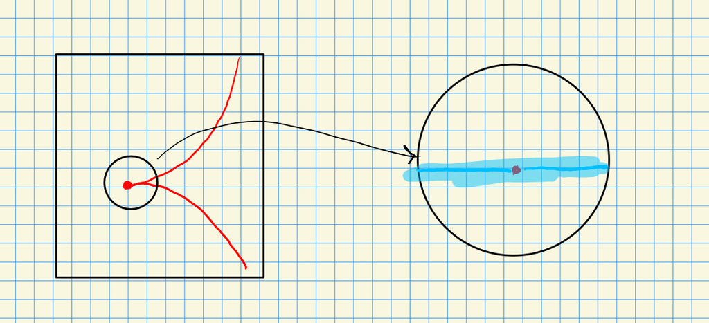

The dimension of a variety is at most the dimension of its tangent spaces.

## 26.2 Smoothness and regularity

Idea: regularity is “almost smooth.”

A ring $(A, m)\in { \mathrm{Noeth} }\mathsf{Loc}\mathsf{CRing}$ is **regular** iff the natural multiplication map $\operatorname{Sym}m/m^2 \twoheadrightarrow\oplus_i m^i/m^{i+1}$ is an isomorphism. For arbitrary $A\in { \mathrm{Noeth} }\mathsf{CRing}$ (not necessarily local), $A$ is *regular* iff $A_m$ is regular for all $m\in \operatorname{mSpec}A$.

- $k[x_1, \cdots, x_{n}]$ is regular.
- $k{\left[\left[ x_1,\cdots, x_n \right]\right] }$ is regular.

Any field is regular local, but regularity is not preserved under extensions. Take ${\mathbb{F}}_p { \left( {t^{1\over p}} \right) } \supseteq{\mathbb{F}}_p { \left( {t} \right) }$ and show
$$\begin{align*}
A \mathrel{\vcenter{:}}={\mathbb{F}}_p { \left( {t^{1\over p}} \right) } \otimes_{{\mathbb{F}}_p { \left( {t} \right) } } {\mathbb{F}}_p { \left( {t^{1\over p}} \right) } \cong {\mathbb{F}}_p { \left( {t^{1\over p}} \right) } { \left[ \scriptstyle {s} \right] } /\left\langle{s^p}\right\rangle
,\end{align*}
which is not reduced. Use that \({\mathbb{F}}_p(t^{1\over p}) = {\mathbb{F}}_p(t)[x]/\left\langle{x^p-t}\right\rangle\), so
\begin{align*}
A = {\mathbb{F}}_p(t)[x,y]/\left\langle{x^p-t, y^p-t}\right\rangle \\
= {\mathbb{F}}_p(t^{1\over p})[y] / \left\langle{y^p - (t^{1\over p})^p }\right\rangle \\
= {\mathbb{F}}_p(t^{1\over p})[y]/\left\langle{y - t^{1\over p}}\right\rangle^p
.\end{align*}$$

If $A\in {\mathsf{Alg}_{/k} }^{\mathrm{fg}}$ and $\mkern 1.5mu\overline{\mkern-1.5muk\mkern-1.5mu}\mkern 1.5mu = \operatorname{cl}^{\mathrm{alg}} k$, then $A$ is **smooth** iff $A\otimes_k { \mkern 1.5mu\overline{\mkern-1.5muk\mkern-1.5mu}\mkern 1.5mu }$ is regular.

Show that a ring $A\in { \mathrm{Noeth} }\mathsf{Loc}\mathsf{CRing}$ is regular iff $\dim A = \dim _{A/m} m/m^2$.

Hint: use that regularity implies equality implies that the map $\pi: \operatorname{Sym}m/m^2\to \oplus m^i/m^{i+1}$ is an isomorphism. Assume this is not an equality, let $f\in \ker \pi$, then $\dim A = \dim \oplus m^i / m ^{i+1} \leq \dim \operatorname{Sym}m/m^2/f < \dim \operatorname{Sym}m/m^2 = \dim m/m^2$, a contradiction.

Show that regular local rings are domains.

Pick nonzero zero divisors, $a,b$ with $ab=0$. Then $\mkern 1.5mu\overline{\mkern-1.5mua\mkern-1.5mu}\mkern 1.5mu, \mkern 1.5mu\overline{\mkern-1.5mub\mkern-1.5mu}\mkern 1.5mu \in m^i/m^{i+1}$ with $\mkern 1.5mu\overline{\mkern-1.5mua\mkern-1.5mu}\mkern 1.5mu \mkern 1.5mu\overline{\mkern-1.5mub\mkern-1.5mu}\mkern 1.5mu = 0$, a contradiction.

# 27 Problem Set 1

AM Ch. 1, 1, 8, 10, 13, 15, 16, and 19.

# 28 Problem Set 2

Show that
$$\begin{align*}
m{\mathbb{Z}}+ n {\mathbb{Z}}= 1 \implies C_m \otimes_{\mathbb{Z}}C_n = 0
,\end{align*}
and more generally
\begin{align*}
C_m\otimes_{\mathbb{Z}}C_n \cong C_d, \qquad d = \gcd(m, n)
.\end{align*}$$

To fix notation, set $C_m \mathrel{\vcenter{:}}=\left\langle{x {~\mathrel{\Big\vert}~}x^m}\right\rangle = \left\{{1=x^0, x, x^2,\cdots, x^{m-1}}\right\}$, written multiplicatively. The $n$th power map $x\mapsto x^n$ induces a SES
$$\begin{align*}
0 \to {\mathbb{Z}}\xrightarrow{({-})^n} {\mathbb{Z}}\to C_n \to 0 \quad \in {\mathbb{Z}{\hbox{-}}\mathsf{Mod}}
.\end{align*}$$

Apply the right-exact functor $({-})\otimes_{\mathbb{Z}}C_m$ and use that ${\mathbb{Z}}\otimes_{\mathbb{Z}}({-}) \simeq\operatorname{id}$ to obtain
$$\begin{align*}
\cdots \to C_m \xrightarrow{({-})^n} C_m \to \operatorname{coker}(({-})^n) \cong C_n\otimes_{\mathbb{Z}}C_m \to 0
,\end{align*}
so it suffices to show surjectivity, that every element in \(C_m\) has an \(n\)th root – i.e that if \(y\in C_m\) then \(y=z^n\) for some \(z\in C_m\). This immediately reduces to finding \(n\)th roots of the generator \(x\), since if \(y=z^n \in C_m\), writing \(y=x^k\) for some \(k\), we have
\begin{align*}
y=x^k = z^n \implies z = x^{k\over n} = (x^{1\over n})^k
,\end{align*}
and thus \(z\) can be expressed as a power of an \(n\)th root of \(x\). That such a root can always be found follows from Bezout’s identity: since \(m, n\) are coprime, there are solutions \((a, b)\) to \(1 = am + bn\), so
\begin{align*}
x = x^1 = x^{am + bn} = x^{am} x^{bn} = (x^b)^n
,\end{align*}
using that \(({-})^m\) annihilates every element in \(C_m\), making \(x^b\) an \(n\)th root of \(x\).$$

More generally, using the same resolution and tensoring with any $A\in {\mathbb{Z}{\hbox{-}}\mathsf{Mod}}$ yields
$$\begin{align*}
\cdots \to A \xrightarrow{({-})^n} A \to \operatorname{coker}( ({-})^n ) \cong {A\over nA} \to 0
,\end{align*}
the submodule of \(n{\hbox{-}}\)divisible elements, and take \(A = C_m\) to get
\begin{align*}
{A\over nA} = {C_m \over n C_m} \cong {{\mathbb{Z}}\over m{\mathbb{Z}}+ n {\mathbb{Z}}}\cong {{\mathbb{Z}}\over d{\mathbb{Z}}} \cong C_d
.\end{align*}$$

Note that similarly applying $\mathop{\mathrm{Hom}}_{{\mathbb{Z}{\hbox{-}}\mathsf{Mod}}}(C_n, {-})$ yields
$$\begin{align*}
\mathop{\mathrm{Hom}}_{{\mathbb{Z}{\hbox{-}}\mathsf{Mod}}}(C_n, C_m) \cong \ker( ({-})^n ) \cong C_d
.\end{align*}$$

Let $A\in \mathsf{CRing}, {\mathfrak{a}}\in \operatorname{Id}(A), M\in {\mathsf{A}{\hbox{-}}\mathsf{Mod}}$. Show that $(A / {\mathfrak{a}}) \otimes_{A} M \cong M / {\mathfrak{a}}M \in {\mathsf{A}{\hbox{-}}\mathsf{Mod}}$.

> Tensor the exact sequence $0 \rightarrow \mathfrak{a} \rightarrow A \rightarrow A / \mathfrak{a} \rightarrow 0$ with $M$.

Applying the hint yields the following:

[figure not shown]

> Link to Diagram

Thus it suffices to show $\operatorname{im}\iota_* \cong {\mathfrak{a}}M$. This is clear since ${\mathfrak{a}}\hookrightarrow A$ is an inclusion, and the natural map $A\otimes_A M { \, \xrightarrow{\sim}\, }M$ is given by $(a, m) \mapsto am$.

Note that there is a map \begin{align*} f: {\mathfrak{a}}\times M &\to {\mathfrak{a}}M \\ (a, m) &\mapsto am ,\end{align*} which is clearly surjective and bilinear, lifting to map out of the tensor product by the universal property. However, it is *not* always an isomorphism, and it being an isomorphism for all ideals is equivalent to $M$ being flat as an $A{\hbox{-}}$module. In other words,
$$\begin{align*}
{\mathfrak{a}}\otimes_A M \cong {\mathfrak{a}}M \quad \forall {\mathfrak{a}}\in\operatorname{Id}(A) \iff M\in {\mathsf{A}{\hbox{-}}\mathsf{Mod}}^\flat
.\end{align*}$$

An easy counterexample:

- $A = k[{\varepsilon}]/\left\langle{{\varepsilon}^2}\right\rangle$
- ${\mathfrak{a}}= \left\langle{{\varepsilon}}\right\rangle \in \operatorname{Id}(A)$
- $M = {\mathfrak{a}}$

Then ${\mathfrak{a}}{ {}^{ \scriptstyle\otimes_{A}^{2} } } \to {\mathfrak{a}}^2$ is not injective. Note that ${\mathfrak{a}}^2=0$ in $A$, so it STS ${\mathfrak{a}}{ {}^{ \scriptstyle\otimes_{A}^{2} } }\neq 0$. The claim is that
$$\begin{align*}
{\mathfrak{a}}{ {}^{ \scriptstyle\otimes_{A}^{2} } } \cong {\mathfrak{a}}{ {}^{ \scriptstyle\otimes_{A/{\mathfrak{a}}}^{2} } } \cong {\mathfrak{a}}{ {}^{ \scriptstyle\otimes_{k}^{2} } }
,\end{align*}
which is the tensor product of two 1-dimensional \(k{\hbox{-}}\)vector spaces, and is thus 1-dimensional over \(k\).$$

Let
$$\begin{align*}
0\to A \xrightarrow{d_1} B \xrightarrow{d_2} C \to 0 \in {\mathsf{A}{\hbox{-}}\mathsf{Mod}}
\end{align*}
with \(A, C\in {\mathsf{A}{\hbox{-}}\mathsf{Mod}}^{\mathrm{fg}}\), and show \(B\in {\mathsf{A}{\hbox{-}}\mathsf{Mod}}^{\mathrm{fg}}\) (i.e. \(B\) is finitely generated as an \(A{\hbox{-}}\)module).$$

Let ${\mathcal{C}}, {\mathcal{A}}$ be generators for $C$ and $A$ respectively, and consider
$$\begin{align*}
{\mathcal{B}}\mathrel{\vcenter{:}}=\left\{{ d_1(a) {~\mathrel{\Big\vert}~}a\in {\mathcal{A}}}\right\}\cup\left\{{\tilde c \in d_2^{-1}(c) {~\mathrel{\Big\vert}~}c\in {\mathcal{C}}}\right\}
,\end{align*}
where the \(\tilde c\) are arbitrarily chosen lifts of the generators \(c\in {\mathcal{C}}\). Then \({\mathcal{B}}\) is a finite set, and the claim is that it generates \(B\) as an \(A{\hbox{-}}\)module.$$

Let $A$ be a ring $\neq 0$.

- Show that $A^{m} \cong A^{n} \Rightarrow m=n$.
- If $\phi: A^{m} \rightarrow A^{n}$ is surjective, then $m \geq n .$
- If $\phi: A^{m} \rightarrow A^{n}$ is injective, is it always the case that $m \leq n$?

> Hint: Let $m$ be a maximal ideal of $A$ and let $\phi: A^{m} \rightarrow A^{n}$ be an isomorphism. Then $1 \otimes \phi:(A / m) \otimes A^{m} \rightarrow(A / m) \otimes A^{n}$ is an isomorphism between vector spaces of dimensions $m$ and $n$ over the field $k=A / m .$ Hence $m=n .$ (Cf. Chapter 3, Exercise 15.)

A partially ordered set $I$ is said to be a directed set if for each pair $i, j$ in $I$ there exists $k \in I$ such that $i \leq k$ and $j \leq k$.

Let $A$ be a ring, let $I$ be a directed set and let $\left(M_{i}\right)_{i \in I}$ be a family of $A$-modules indexed by $\cdot I$. For each pair $i, j$ in $I$ such that $i \leq j$, let $\mu_{i j}: M_{i} \rightarrow M$, be an $A$-homomorphism, and suppose that the following axioms are satisfied:

1. $\mu_{l t}$ is the identity mapping of $M_{i}$, for all $i \in I$;
2. $\mu_{i k}=\mu_{j k} \circ \mu_{l y}$ whenever $i \leq j \leq k$.

Then the modules $M_{1}$ and homomorphisms $\mu_{i f}$ are said to form a direct system $\mathbf{M}=\left(M_{t}, \mu_{t j}\right)$ over the directed set $I$.

We shall construct an $A$-module $M$ called the direct limit of the direct system M. Let $C$ be the direct sum of the $M_{1}$, and identify each module $M_{i}$ with its canonical image in $C$. Let $D$ be the submodule of $C$ generated by all elements of the form $x_{i}-\mu_{t j}\left(x_{i}\right)$ where $i \leq j$ and $x_{i} \in M_{i}$. Let $M=C / D$, let $\mu: C \rightarrow M$ be the projection and let $\mu_{i}$ be the restriction of $\mu$ to $M_{i}$.

The module $M$, or more correctly the pair consisting of $M$ and the family of homomorphisms $\mu_{i}: M_{1} \rightarrow M$, is called the direct limit of the direct system $M$, and is written $\colim_i M_{i}$. From the construction it is clear that $\mu_{t}=\mu_{j} \circ \mu_{i f}$ whenever $i \leq j$.

Show that the direct limit is characterized (up to isomorphism) by the following property. Let $N$ be an $A$-module and for each $i \in I$ let $\alpha_{i}: M_{t} \rightarrow N$ be an $A-$ module homomorphism such that $\alpha_{t}=\alpha_{j} \circ \mu_{t s}$ whenever $i \leq j$. Then there exists a unique homomorphism $\alpha: M \rightarrow N$ such that $\alpha_{1}=\alpha \circ \mu_{t}$ for all $i \in I$.

Keeping the same notation as in Exercise 14 , let $N$ be any $A$-module. Then $\left(M_{1} \otimes N, \mu_{i j} \otimes 1\right)$ is a direct system; let $P=\colim_i \left(M_{i} \otimes N\right)$ be its direct limit.

For each $i \in I$ we have a homomorphism
$$\begin{align*}
\mu_{i} \otimes 1: M_{i} \otimes N \rightarrow M \otimes N
,\end{align*}
hence by Exercise 16 a homomorphism \(\psi: P \rightarrow M \otimes N\). Show that \(\psi\) is an isomorphism, so that
\begin{align*}
\colim_i \left(M_{i} \otimes N\right) \cong\left(\colim_{i} M_{i}\right) \otimes N .
\end{align*}$$

> Hint: For each $i \in I$, let
> $$\begin{align*}
> g_{i}: M_{t} \times N \rightarrow M_{t} \otimes N
> \end{align*}
> be the canonical bilinear mapping. Passing to the limit we obtain a mapping \(g: M \times N \rightarrow P\). Show that \(g\) is \(A\)-bilinear and hence define a homomorphism \(\phi: M \otimes N \rightarrow P\). Verify that \(\phi \circ \psi\) and \(\psi \circ \phi\) are identity mappings.$$

# 29 Problem Set 3

Let $S$ be a multiplicatively closed subset of a ring $A$, and let $M$ be a finitely generated $A$-module. Prove that $S^{-1} M=0$ if and only if there exists $s \in S$ such that $s M=0$.

Let $f: A \rightarrow B$ be a homomorphism of rings and let $S$ be a multiplicatively closed subset of $A$. Let $T=f(S)$. Show that $S^{-1} B$ and $T^{-1} B$ are isomorphic as $S^{-1} A$-modules.

Let $A$ be an integral domain and $M$ an $A$-module. An element $x \in M$ is a torsion element of $M$ if Ann $(x) \neq 0$, that is if $x$ is killed by some non-zero element of $A$. Show that the torsion elements of $M$ form a submodule of $M$. This submodule is called the torsion submodule of $M$ and is denoted by $T(M)$. If $T(M)=0$, the module $M$ is said to be torsion-free. Show that

1. If $M$ is any $A$-module, then $M / T(M)$ is torsion-free.
2. If $f: M \rightarrow N$ is a module homomorphism, then $f(T(M)) \subseteq T(N)$.
3. If $0 \rightarrow M^{\prime} \rightarrow M \rightarrow M^{\prime \prime}$ is an exact sequence, then the sequence $0 \rightarrow T\left(M^{\prime}\right)$ $\rightarrow T(M) \rightarrow T\left(M^{\prime \prime}\right)$ is exact.
4. If $M$ is any $A$-module, then $T(M)$ is the kernel of the mapping $x \mapsto 1 \otimes x$ of $M$ into $K \otimes_{1} M$, where $K$ is the field of fractions of $A$.

> For iv), show that $K$ may be regarded as the direct limit of its submodules $A \xi(\xi \in K)$; using Chapter 1, Exercise 15 and Exercise 20, show that if $1 \otimes x=0$ in $K \otimes M$ then $1 \otimes x=0$ in $A \xi \otimes M$ for some $\xi \neq 0$. Deduce that $\xi^{-1} x=0$.

Show that $\mathbb{Q}$ is a flat $\mathbb{Z}$-module which is not free

Prove that if $B, C$ are $A$ algebras, the tensor product algebra $B \otimes_{A} C$ has the following universal property: an algebra homomorphism $B \otimes_{A} C \rightarrow S$ is the same as a pair of algebra homomorphisms $B \rightarrow S, C \rightarrow S$.

# 30 Problem Set 4

Let $f: M \rightarrow N$ be a map of modules over a local ring $A$, with $N$ finitely generated. Show that if the induced map $M / \mathfrak{m} M \rightarrow N / \mathfrak{m} N$ is surjective, the same is true for $f$. Does a similar statement hold for injectivity?

Let $M$ be a finitely-generated module over a ring $A$, and let $p$ be a prime ideal of $A$. Suppose $M_{p}=0$. Show that there exists a finite set $x_{1}, \cdots, x_{n}$ of elements of $A \backslash \mathfrak{p}$ such that the localization of $M$ at the multiplicative set generated by the $x_{i}$ is zero.

Let $M$ be a finitely-generated module over a Noetherian ring $A$ (that means any submodule of a finitely-generated module is finitely generated), and let $p$ be a prime ideal of $A$. Suppose $M_{p}$ is free. Show that there exists a finite set $x_{1}, \cdots, x_{n}$ of elements of $A \backslash p$ such that the localization of $M$ at the multiplicative set generated by the $x_{i}$ is free.

Give an example of a module $M$ over a ring $A$ such that $M_{p}$ is free for each prime ideal p of $A$, but $M$ itself is not free. Such modules are called locally free.

Give an example of a flat module which is not projective.

Write a careful proof of the Cayley-Hamilton theorem over an arbitrary field.

# 31 Problem Set 5

HW 5 (due Feb 17): AM Chapter 2, exercises 24, 25, 26

1. Let $M$ be an $A$-module and let $F_{\bullet}: \cdots \rightarrow F_{2} \rightarrow F_{1} \rightarrow F_{0}$ be a flat resolution of $M$, i.e. a chain complex with each $F_{i}$ flat, and such that $H_{i}\left(F_{\bullet}\right)=0$ for $i>0$ and $H_{0}\left(F_{\bullet}\right)=M$. Show that for any $A$-module $N, H_{i}\left(F_{\bullet} \otimes_{A} N\right)=\operatorname{Tor}_{i}^{A}(M, N)$.
2. Let $M$ be a finitely-generated flat module over a Noetherian local ring $A$. Show that $M$ is free.
3. Carefully check that Ext is well-defined, i.e. independent of the choice of injective resolution in the definition.
4. Compute $\operatorname{Ext}_{\mathbb{Z}}^{i}(\mathbb{Z} / p \mathbb{Z}, \mathbb{Z})$ for each prime $p$.

# 32 Problem Set 6

HW 6 (due Feb 24): AM Chapter 5, exercises 1, 2, 10, 12, 14, and Chapter 6, exercises 2 and 5

# 33 Problem Set 7

HW 7 (due Thursday, March 17, after Spring Break):

1. Let $M$ be an $A$-module, and $f \in A$. Construct an isomorphism between $M_{f}$ and $\underset{\longrightarrow}{\rightarrow} M \stackrel{\cdot f}{\rightarrow} M \stackrel{\cdot f}{\rightarrow} M \stackrel{\cdot f}{\rightarrow} \cdots$.
2. Construct a module $M$ over a ring $A$ such that for each prime ideal $\mathfrak{p}$ of $A, M_{\mathfrak{p}}$ is finitely generated, but $M$ is not finitely-generated.
3. Let $M$ be a finitely-generated module over a Noetherian ring. Show that $M=0$ if and only if the support of $M$ is empty.
4. Suppose $\operatorname{Spec}(A)=V_{1} \sqcup V_{2}$, where $V_{1}, V_{2}$ are clopen disjoint subsets. Show that there exists a direct sum decomposition $A=A_{1} \oplus A_{2}$ such that the natural quotient maps $A \rightarrow A_{i}$ induce isomorphisms $\operatorname{Spec}\left(A_{i}\right) \rightarrow V_{i}$ for $i=1,2$.
5. Show that exactness of a long exact sequence is a local property.
6. Let $A$ be a Noetherian local domain with residue field $k$ and fraction field $K$, and $M$ a finitely-generated $A$-module. Show that the following are equivalent:
7. $M$ is free
8. $\operatorname{dim}_{k} M \otimes_{A} k=\operatorname{dim}_{K} M \otimes_{A} K$.
9. Let $A$ be a Noetherian ring and $M$ finitely-generated. Show that the following are equivalent:
10. $M$ is locally free
11. $M$ is projective
12. $M$ is flat.
13. Show that any Artinian ring is Noetherian
14. Show that if $A$ is a Noetherian ring such that $\operatorname{Spec}(A)$ is Hausdorff, then $A$ is Artinian.

# 34 Problem Set 8

HW 8 (due March 31)

1. Give an example (with proof) of a rank one locally free module over a Dedekind domain that is not free.
2. Give an example (with proof) of a Noetherian domain of Krull dimension one which is not a Dedekind domain.
3. Let $M$ be a finitely generated module over a Dedekind domain $A$. Show that $M$ has a projective resolution of length two. Conclude that Tor ${ }_{i}^{A}(M,-)$ and $\operatorname{Ext}_{A}^{i}(M,-)$ equal zero for $i>1$.
4. Let $M, N$ be a finitely generated modules over a Dedekind domain $A$. Show that $\operatorname{Tor}_{1}^{A}(M, N)$ is a torsion $A$-module. Can you identify its support?
5. Give an example of a Dedekind domain with uncountable Picard group.
6. Let $k$ be a field. Show that the Picard group of $k[t]$ is trivial, i.e. any rank one locally free sheaf over $k[t]$ is free.
7. Give an example of a domain with a maximal non-zero ideal $\mathfrak{m}$ such that $\mathfrak{m}^{2}=\mathfrak{m}$.

# 35 Bibliography

[^1]: A very important result! Marks the end of invariant theory historically.